# Full_code_notebook_TSF_project_Benedict_Egwuchukwu

## Problem Statement

For this particular assignment, the data of different types of wine sales in the 20th century is to be analysed. Both of these data are from the same company but of different wines. As an analyst in the ABC Estate Wines, you are tasked to analyse and forecast Wine Sales in the 20th century.

## Importing necessary libraries

```python
from statsmodels.tsa.arima.model import ARIMA as ar
from statsmodels.tsa.seasonal import seasonal_decompose
from sklearn.linear_model import LinearRegression
import statsmodels as st
from statsmodels.tsa.api import ExponentialSmoothing, SimpleExpSmoothing, Holt
from statsmodels.tsa.arima.model import ARIMA
import itertools
from statsmodels.graphics.tsaplots import plot_acf, plot_pacf

import numpy as np
import pandas as pd
from sklearn import metrics
import matplotlib.pyplot as plt
#import plotly.offline as py

%matplotlib inline
import seaborn as sns
from pylab import rcParams

import warnings
warnings.filterwarnings("ignore")
```

## Loading the dataset

```python
df = pd.read_csv("Sparkling.csv")
df
```

|  | YearMonth | Sparkling |
| --- | --- | --- |
| 0 | 1980-01 | 1686 |
| 1 | 1980-02 | 1591 |
| 2 | 1980-03 | 2304 |
| 3 | 1980-04 | 1712 |
| 4 | 1980-05 | 1471 |
| ... | ... | ... |
| 182 | 1995-03 | 1897 |
| 183 | 1995-04 | 1862 |
| 184 | 1995-05 | 1670 |
| 185 | 1995-06 | 1688 |
| 186 | 1995-07 | 2031 |

187 rows × 2 columns

## Data Overview

```python
# Displaying the first few rows of the dataset
df.head()
```

|  | YearMonth | Sparkling |
| --- | --- | --- |
| 0 | 1980-01 | 1686 |
| 1 | 1980-02 | 1591 |
| 2 | 1980-03 | 2304 |
| 3 | 1980-04 | 1712 |
| 4 | 1980-05 | 1471 |

```python
# Checking the shape of the dataset
print(f"There are {df.shape[0]} rows and {df.shape[1]} columns.")
```

```
There are 187 rows and 2 columns.
```

```python
# Checking the datatypes and if there are null values
df.info()
```

```
<class 'pandas.core.frame.DataFrame'>
RangeIndex: 187 entries, 0 to 186
Data columns (total 2 columns):
 #   Column     Non-Null Count  Dtype
---  ------     --------------  -----
 0   YearMonth  187 non-null    object
 1   Sparkling  187 non-null    int64
dtypes: int64(1), object(1)
memory usage: 3.1+ KB
```

#### Observations

- From the above, the YearMonth variable is an object datatype but needs to be in a datetime format.
- The Sparkling variable is a numerical data type.

### Data Preprocessing

```python
# Create a new time stamp in the datetime datatype format
Time_Stamp = pd.date_range(start = '1980-01-01', periods = len(df), freq = 'M')
Time_Stamp
```

```
DatetimeIndex(['1980-01-31', '1980-02-29', '1980-03-31', '1980-04-30',
               '1980-05-31', '1980-06-30', '1980-07-31', '1980-08-31',
               '1980-09-30', '1980-10-31',
               ...
               '1994-10-31', '1994-11-30', '1994-12-31', '1995-01-31',
               '1995-02-28', '1995-03-31', '1995-04-30', '1995-05-31',
               '1995-06-30', '1995-07-31'],
              dtype='datetime64[ns]', length=187, freq='ME')
```

```python
# Adding Time_Stamp to the Dataset
df['Time_Stamp'] = Time_Stamp
df.head()
```

|  | YearMonth | Sparkling | Time_Stamp |
| --- | --- | --- | --- |
| 0 | 1980-01 | 1686 | 1980-01-31 |
| 1 | 1980-02 | 1591 | 1980-02-29 |
| 2 | 1980-03 | 2304 | 1980-03-31 |
| 3 | 1980-04 | 1712 | 1980-04-30 |
| 4 | 1980-05 | 1471 | 1980-05-31 |

```python
# Set the Time_Stamp as the index
df.set_index(keys = "Time_Stamp", inplace = True)
df
```

| Time_Stamp | YearMonth | Sparkling |
| --- | --- | --- |
| 1980-01-31 | 1980-01 | 1686 |
| 1980-02-29 | 1980-02 | 1591 |
| 1980-03-31 | 1980-03 | 2304 |
| 1980-04-30 | 1980-04 | 1712 |
| 1980-05-31 | 1980-05 | 1471 |
| ... | ... | ... |
| 1995-03-31 | 1995-03 | 1897 |
| 1995-04-30 | 1995-04 | 1862 |
| 1995-05-31 | 1995-05 | 1670 |
| 1995-06-30 | 1995-06 | 1688 |
| 1995-07-31 | 1995-07 | 2031 |

187 rows × 2 columns

```python
# Drop the YearMonth variable
df.drop(["YearMonth"], axis = 1, inplace = True)
df
```

| Time_Stamp | Sparkling |
| --- | --- |
| 1980-01-31 | 1686 |
| 1980-02-29 | 1591 |
| 1980-03-31 | 2304 |
| 1980-04-30 | 1712 |
| 1980-05-31 | 1471 |
| ... | ... |
| 1995-03-31 | 1897 |
| 1995-04-30 | 1862 |
| 1995-05-31 | 1670 |
| 1995-06-30 | 1688 |
| 1995-07-31 | 2031 |

187 rows × 1 columns

```python
# Check the shape of the dataset
print(f"There are {df.shape[0]} rows and {df.shape[1]} columns.")
```

```
There are 187 rows and 1 columns.
```

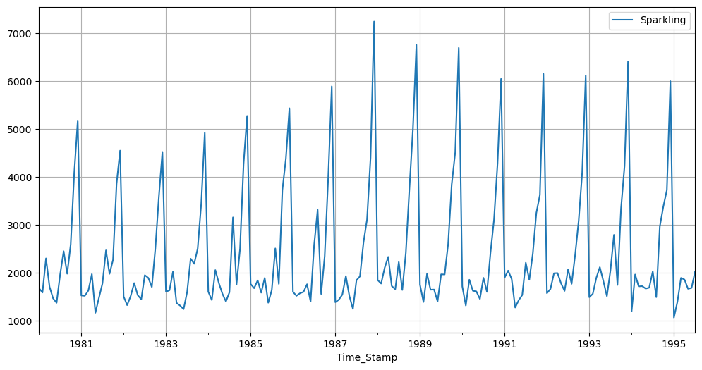

```python
# Visualize the dataset
df.plot(figsize = (12, 6))
plt.grid()
```

### Checking for missing values

```python
# Checking for missing values
df.isna().sum()
```

```
Sparkling    0
dtype: int64
```

#### Observations

- There are no missing data in the dataset.

### Checking for outliers

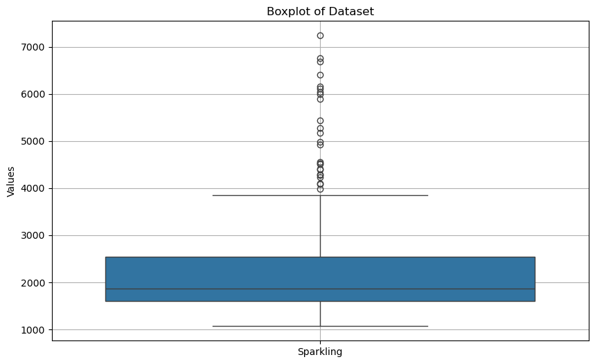

```python
# Create a boxplot to check for outliers
plt.figure(figsize = (10, 6))
sns.boxplot(data = df)
plt.title("Boxplot of Dataset")
plt.ylabel("Values")
plt.grid(True)
plt.show()
```

#### Observations

- There are some outliers that might need treatment depending on the context.
- All outliers are after the 75th percentile.

```python
# Calculate Q1 (25th percentile) and Q3 (75th percentile)
Q1 = df["Sparkling"].quantile(0.25)
Q3 = df["Sparkling"].quantile(0.75)
IQR = Q3 - Q1
IQR
```

```
944.0
```

```python
# Define upper bound for outliers
upper_bound = Q3 + 1.5 * IQR
upper_bound
```

```
3965.0
```

```python
# Identify and count the outliers
outliers = df["Sparkling"] > upper_bound
print(df[outliers])
print(outliers.sum())
```

```
            Sparkling
Time_Stamp
1980-11-30       4087
1980-12-31       5179
1981-12-31       4551
1982-12-31       4524
1983-12-31       4923
1984-11-30       4273
1984-12-31       5274
1985-11-30       4388
1985-12-31       5434
1986-11-30       3987
1986-12-31       5891
1987-11-30       4405
1987-12-31       7242
1988-11-30       4988
1988-12-31       6757
1989-11-30       4514
1989-12-31       6694
1990-11-30       4286
1990-12-31       6047
1991-12-31       6153
1992-11-30       4096
1992-12-31       6119
1993-11-30       4227
1993-12-31       6410
1994-12-31       5999
25
```

#### Observations

- All outliers occur during the festive period (November and December), speaking more to seasonality.

```python
# Replace outliers with respective quantiles
cleaned = df["Sparkling"].clip(upper = upper_bound)
cleaned
df_cleaned = df.copy()
df_cleaned["Sparkling"] = cleaned
df_cleaned.head(12)
```

| Time_Stamp | Sparkling |
| --- | --- |
| 1980-01-31 | 1686 |
| 1980-02-29 | 1591 |
| 1980-03-31 | 2304 |
| 1980-04-30 | 1712 |
| 1980-05-31 | 1471 |
| 1980-06-30 | 1377 |
| 1980-07-31 | 1966 |
| 1980-08-31 | 2453 |
| 1980-09-30 | 1984 |
| 1980-10-31 | 2596 |
| 1980-11-30 | 3965 |
| 1980-12-31 | 3965 |

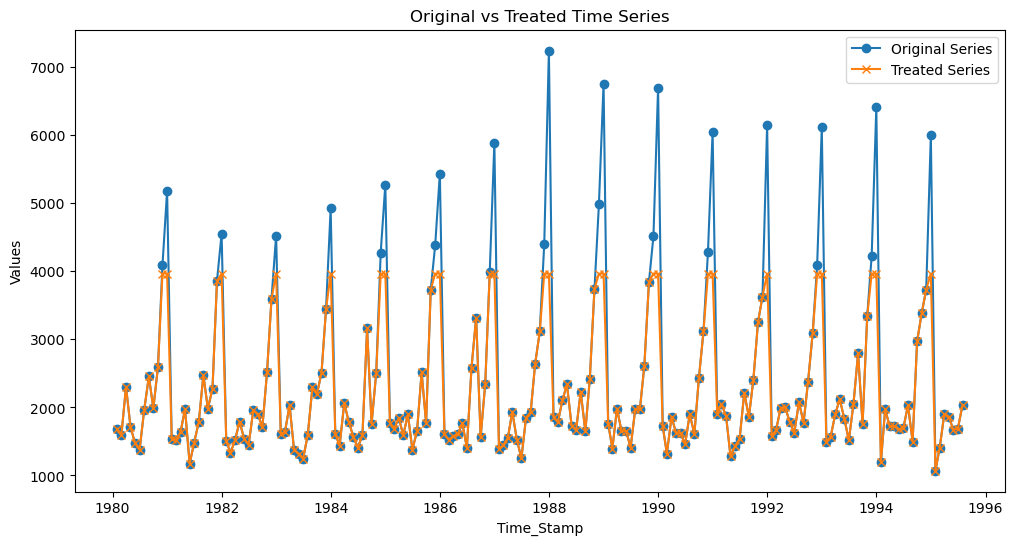

```python
# Visualize the original dataset alongside the treated dataset
plt.figure(figsize = (12, 6))

# Plot the original dataset
plt.plot(df, label = "Original Series", marker = "o")

# Plot the treated dataset
plt.plot(df_cleaned, label = "Treated Series", marker = "x")

# Add titles and labels
plt.title("Original vs Treated Time Series")
plt.xlabel("Time_Stamp")
plt.ylabel("Values")
plt.legend()

# Display the plot
plt.show()
```

#### Observations

- From the above chart, the spikes are a natural part of the time series (i.e. seasonal effects or expected fluctuations) and would not need treatment.
- The trend should be preserved given that the spikes happen during the holiday seasons.

## Exploratory Data Analysis (EDA)

### Bivariate Analysis

#### Timestamp vs Sparkling

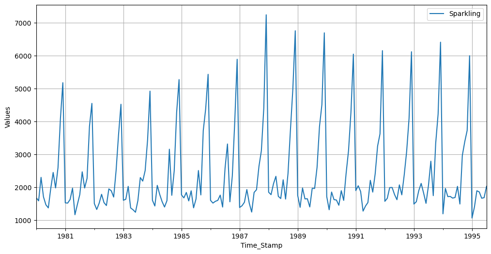

```python
## Let's plot the sparkling vs timestamp
df.plot(figsize = (12, 6))
plt.xlabel("Time_Stamp")
plt.ylabel("Values")
plt.grid()
```

#### Observations

- There seems to be no trend in the dataset. However, there is a seasonal pattern.

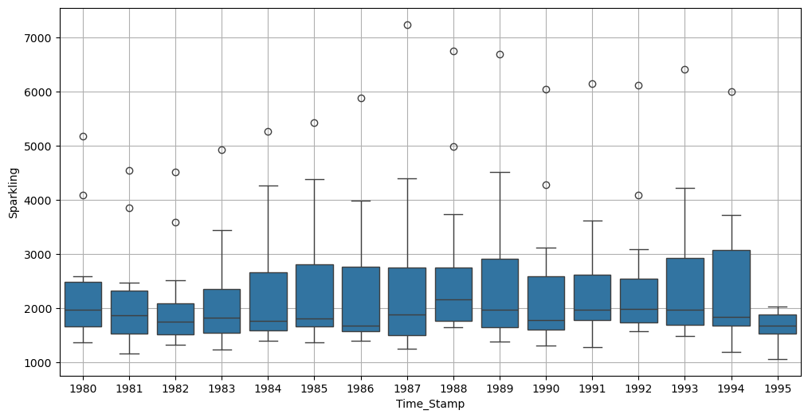

```python
# Check the relationship between the 'Sparkling' column and 'Time_Stamp' on a yearly basis
plt.figure(figsize = (12, 6))
sns.boxplot(x = df.index.year, y = df['Sparkling'])
plt.grid()
```

#### Observations

- The yearly boxplots also shows that the wine Sales have no trend across the years available.
- There are outliers in the sale of Sparkling wine across the various years except 1995. This is because the data in 1995 doesn't reach December.
- The highest mean sale for Sparkling wine is shown in year 1988 and the lowest sales are in the year of 1995 (due to paucity of data).

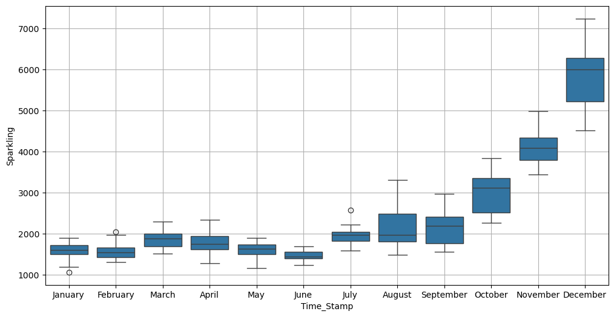

```python
# Check the relationship between the 'Sparkling' column and 'Time_Stamp' on a monthly basis
plt.figure(figsize = (12, 6))
sns.boxplot(x = df.index.month_name(), y = df['Sparkling'])
plt.grid()
```

#### Observations

- There is a clear distinction of wine sales within different months spread across various years. The highest of such numbers are being recorded in the month of November-December across various years.
- Sales are quite low in the first half of the year.

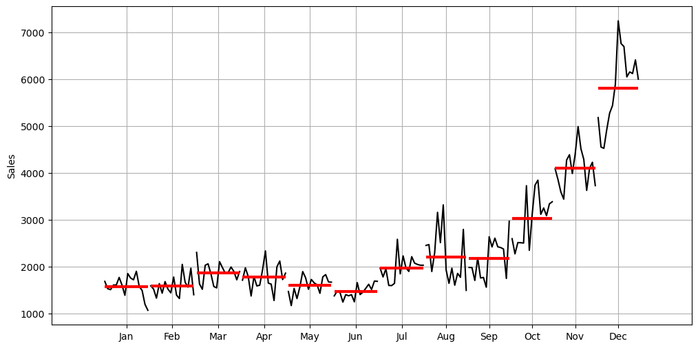

```python
from statsmodels.graphics.tsaplots import month_plot

fig, ax = plt.subplots(figsize = (12, 6))
month_plot(df["Sparkling"], ylabel = "Sales", ax = ax)
plt.grid()
plt.show()
```

#### Observations

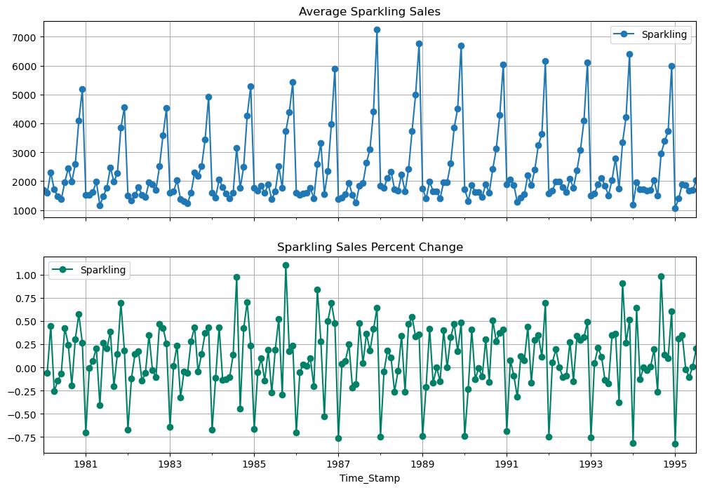

```python
# Group by date and get average Sparkling sales and precent change
average = df.groupby(df.index)["Sparkling"].mean()
pct_change = df.groupby(df.index)["Sparkling"].sum().pct_change()

fig, (axis1, axis2) = plt.subplots(2, 1, sharex = True, figsize = (12, 8))

# Plot average Sparkling sales over time(year-month)
ax1 = average.plot(legend = True, ax = axis1, marker = "o", title = "Average Sparkling Sales", grid = True)
ax1.set_xticks(range(len(average)))
ax1.set_xticklabels(average.index.tolist())

# Plot precent change for Sparkling sales over time(year-month)
ax2 = pct_change.plot(legend = True, ax = axis2, marker = "o", colormap = "summer", title = "Sparkling Sales Percent Change", grid = True)
```

```python
# Create a pivot table
monthly_sales_across_years = pd.pivot_table(df, values = "Sparkling", columns = df.index.month, index = df.index.year)
monthly_sales_across_years
```

| Time_Stamp | 1 | 2 | 3 | 4 | 5 | 6 | 7 | 8 | 9 | 10 | 11 | 12 |
| --- | --- | --- | --- | --- | --- | --- | --- | --- | --- | --- | --- | --- |
| 1980 | 1686.0 | 1591.0 | 2304.0 | 1712.0 | 1471.0 | 1377.0 | 1966.0 | 2453.0 | 1984.0 | 2596.0 | 4087.0 | 5179.0 |
| 1981 | 1530.0 | 1523.0 | 1633.0 | 1976.0 | 1170.0 | 1480.0 | 1781.0 | 2472.0 | 1981.0 | 2273.0 | 3857.0 | 4551.0 |
| 1982 | 1510.0 | 1329.0 | 1518.0 | 1790.0 | 1537.0 | 1449.0 | 1954.0 | 1897.0 | 1706.0 | 2514.0 | 3593.0 | 4524.0 |
| 1983 | 1609.0 | 1638.0 | 2030.0 | 1375.0 | 1320.0 | 1245.0 | 1600.0 | 2298.0 | 2191.0 | 2511.0 | 3440.0 | 4923.0 |
| 1984 | 1609.0 | 1435.0 | 2061.0 | 1789.0 | 1567.0 | 1404.0 | 1597.0 | 3159.0 | 1759.0 | 2504.0 | 4273.0 | 5274.0 |
| 1985 | 1771.0 | 1682.0 | 1846.0 | 1589.0 | 1896.0 | 1379.0 | 1645.0 | 2512.0 | 1771.0 | 3727.0 | 4388.0 | 5434.0 |
| 1986 | 1606.0 | 1523.0 | 1577.0 | 1605.0 | 1765.0 | 1403.0 | 2584.0 | 3318.0 | 1562.0 | 2349.0 | 3987.0 | 5891.0 |
| 1987 | 1389.0 | 1442.0 | 1548.0 | 1935.0 | 1518.0 | 1250.0 | 1847.0 | 1930.0 | 2638.0 | 3114.0 | 4405.0 | 7242.0 |
| 1988 | 1853.0 | 1779.0 | 2108.0 | 2336.0 | 1728.0 | 1661.0 | 2230.0 | 1645.0 | 2421.0 | 3740.0 | 4988.0 | 6757.0 |
| 1989 | 1757.0 | 1394.0 | 1982.0 | 1650.0 | 1654.0 | 1406.0 | 1971.0 | 1968.0 | 2608.0 | 3845.0 | 4514.0 | 6694.0 |
| 1990 | 1720.0 | 1321.0 | 1859.0 | 1628.0 | 1615.0 | 1457.0 | 1899.0 | 1605.0 | 2424.0 | 3116.0 | 4286.0 | 6047.0 |
| 1991 | 1902.0 | 2049.0 | 1874.0 | 1279.0 | 1432.0 | 1540.0 | 2214.0 | 1857.0 | 2408.0 | 3252.0 | 3627.0 | 6153.0 |
| 1992 | 1577.0 | 1667.0 | 1993.0 | 1997.0 | 1783.0 | 1625.0 | 2076.0 | 1773.0 | 2377.0 | 3088.0 | 4096.0 | 6119.0 |
| 1993 | 1494.0 | 1564.0 | 1898.0 | 2121.0 | 1831.0 | 1515.0 | 2048.0 | 2795.0 | 1749.0 | 3339.0 | 4227.0 | 6410.0 |
| 1994 | 1197.0 | 1968.0 | 1720.0 | 1725.0 | 1674.0 | 1693.0 | 2031.0 | 1495.0 | 2968.0 | 3385.0 | 3729.0 | 5999.0 |
| 1995 | 1070.0 | 1402.0 | 1897.0 | 1862.0 | 1670.0 | 1688.0 | 2031.0 | NaN | NaN | NaN | NaN | NaN |

### Decomposition

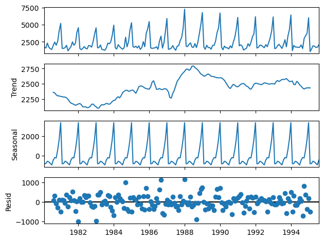

```python
# Decompose the time series additively
decomposition = seasonal_decompose(df, model = "addictive")
decomposition.plot();
```

```python
trend = decomposition.trend
seasonality = decomposition.seasonal
residual = decomposition.resid

print("Trend", "\n", trend.head(12), "\n")
print("Seasonality", "\n", seasonality.head(12), "\n")
print("Residual", "\n", residual.head(12), "\n")
```

```
Trend
 Time_Stamp
1980-01-31            NaN
1980-02-29            NaN
1980-03-31            NaN
1980-04-30            NaN
1980-05-31            NaN
1980-06-30            NaN
1980-07-31    2360.666667
1980-08-31    2351.333333
1980-09-30    2320.541667
1980-10-31    2303.583333
1980-11-30    2302.041667
1980-12-31    2293.791667
Name: trend, dtype: float64

Seasonality
 Time_Stamp
1980-01-31    -854.260599
1980-02-29    -830.350678
1980-03-31    -592.356630
1980-04-30    -658.490559
1980-05-31    -824.416154
1980-06-30    -967.434011
1980-07-31    -465.502265
1980-08-31    -214.332821
1980-09-30    -254.677265
1980-10-31     599.769957
1980-11-30    1675.067179
1980-12-31    3386.983846
Name: seasonal, dtype: float64

Residual
 Time_Stamp
1980-01-31           NaN
1980-02-29           NaN
1980-03-31           NaN
1980-04-30           NaN
1980-05-31           NaN
1980-06-30           NaN
1980-07-31     70.835599
1980-08-31    315.999487
1980-09-30    -81.864401
1980-10-31   -307.353290
1980-11-30    109.891154
1980-12-31   -501.775513
Name: resid, dtype: float64
```

### Check for Addictive Assumptions

```python
residual.mean()
```

```
-1.2088458994707376
```

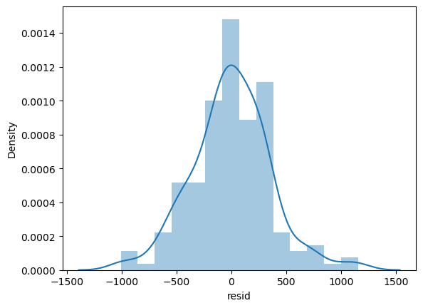

```python
# Normality Distribution of Resid
from scipy.stats import shapiro

sns.distplot(residual)
```

```python
shapiro(residual.dropna())
```

```
ShapiroResult(statistic=0.9833056372432126, pvalue=0.03433683203800602)
```

### Multiplicative Decomposition

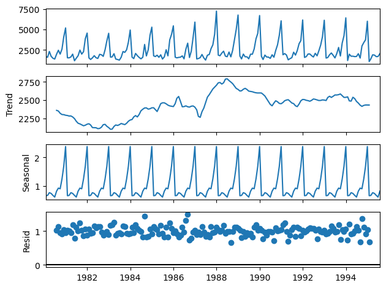

```python
# Decompose the time series multiplicatively
decomposition = seasonal_decompose(df, model = "multiplicative")
decomposition.plot();
```

```python
trend = decomposition.trend
seasonality = decomposition.seasonal
residual = decomposition.resid

print("Trend", "\n", trend.head(12), "\n")
print("Seasonality", "\n", seasonality.head(12), "\n")
print("Residual", "\n", residual.head(12), "\n")
```

```
Trend
 Time_Stamp
1980-01-31            NaN
1980-02-29            NaN
1980-03-31            NaN
1980-04-30            NaN
1980-05-31            NaN
1980-06-30            NaN
1980-07-31    2360.666667
1980-08-31    2351.333333
1980-09-30    2320.541667
1980-10-31    2303.583333
1980-11-30    2302.041667
1980-12-31    2293.791667
Name: trend, dtype: float64

Seasonality
 Time_Stamp
1980-01-31    0.649843
1980-02-29    0.659214
1980-03-31    0.757440
1980-04-30    0.730351
1980-05-31    0.660609
1980-06-30    0.603468
1980-07-31    0.809164
1980-08-31    0.918822
1980-09-30    0.894367
1980-10-31    1.241789
1980-11-30    1.690158
1980-12-31    2.384776
Name: seasonal, dtype: float64

Residual
 Time_Stamp
1980-01-31         NaN
1980-02-29         NaN
1980-03-31         NaN
1980-04-30         NaN
1980-05-31         NaN
1980-06-30         NaN
1980-07-31    1.029230
1980-08-31    1.135407
1980-09-30    0.955954
1980-10-31    0.907513
1980-11-30    1.050423
1980-12-31    0.946770
Name: resid, dtype: float64
```

### Check for Multiplicative Assumptions

```python
residual.mean()
```

```
0.9997456359115032
```

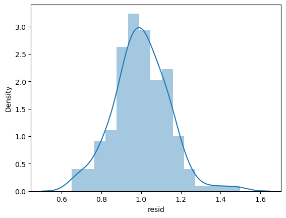

```python
# Normality Distribution of Resid
sns.distplot(residual)
```

```python
shapiro(residual.dropna())
```

```
ShapiroResult(statistic=0.9859993833004654, pvalue=0.07803310394786477)
```

```python
df.describe()
```

|  | Sparkling |
| --- | --- |
| count | 187.000000 |
| mean | 2402.417112 |
| std | 1295.111540 |
| min | 1070.000000 |
| 25% | 1605.000000 |
| 50% | 1874.000000 |
| 75% | 2549.000000 |
| max | 7242.000000 |

## Data Preparation for Modeling

```python
# Split the data into train and test and plot the training and test data
df_train = df[df.index <= "1991"]
df_test = df[df.index > "1991"]

print("Training Data")
display(df_train)
print("Test Data")
display(df_test)
```

```
Training Data
```

| Time_Stamp | Sparkling |
| --- | --- |
| 1980-01-31 | 1686 |
| 1980-02-29 | 1591 |
| 1980-03-31 | 2304 |
| 1980-04-30 | 1712 |
| 1980-05-31 | 1471 |
| ... | ... |
| 1990-08-31 | 1605 |
| 1990-09-30 | 2424 |
| 1990-10-31 | 3116 |
| 1990-11-30 | 4286 |
| 1990-12-31 | 6047 |

132 rows × 1 columns

```
Test Data
```

| Time_Stamp | Sparkling |
| --- | --- |
| 1991-01-31 | 1902 |
| 1991-02-28 | 2049 |
| 1991-03-31 | 1874 |
| 1991-04-30 | 1279 |
| 1991-05-31 | 1432 |
| 1991-06-30 | 1540 |
| 1991-07-31 | 2214 |
| 1991-08-31 | 1857 |
| 1991-09-30 | 2408 |
| 1991-10-31 | 3252 |
| 1991-11-30 | 3627 |
| 1991-12-31 | 6153 |
| 1992-01-31 | 1577 |
| 1992-02-29 | 1667 |
| 1992-03-31 | 1993 |
| 1992-04-30 | 1997 |
| 1992-05-31 | 1783 |
| 1992-06-30 | 1625 |
| 1992-07-31 | 2076 |
| 1992-08-31 | 1773 |
| 1992-09-30 | 2377 |
| 1992-10-31 | 3088 |
| 1992-11-30 | 4096 |
| 1992-12-31 | 6119 |
| 1993-01-31 | 1494 |
| 1993-02-28 | 1564 |
| 1993-03-31 | 1898 |
| 1993-04-30 | 2121 |
| 1993-05-31 | 1831 |
| 1993-06-30 | 1515 |
| 1993-07-31 | 2048 |
| 1993-08-31 | 2795 |
| 1993-09-30 | 1749 |
| 1993-10-31 | 3339 |
| 1993-11-30 | 4227 |
| 1993-12-31 | 6410 |
| 1994-01-31 | 1197 |
| 1994-02-28 | 1968 |
| 1994-03-31 | 1720 |
| 1994-04-30 | 1725 |
| 1994-05-31 | 1674 |
| 1994-06-30 | 1693 |
| 1994-07-31 | 2031 |
| 1994-08-31 | 1495 |
| 1994-09-30 | 2968 |
| 1994-10-31 | 3385 |
| 1994-11-30 | 3729 |
| 1994-12-31 | 5999 |
| 1995-01-31 | 1070 |
| 1995-02-28 | 1402 |
| 1995-03-31 | 1897 |
| 1995-04-30 | 1862 |
| 1995-05-31 | 1670 |
| 1995-06-30 | 1688 |
| 1995-07-31 | 2031 |

```python
# Check shape of the train and test dataset
print(f"In the training dataset, there are {df_train.shape[0]} rows and {df_train.shape[1]} column.")
print(f"In the test dataset, there are {df_test.shape[0]} rows and {df_test.shape[1]} column.")
```

```
In the training dataset, there are 132 rows and 1 column.
In the test dataset, there are 55 rows and 1 column.
```

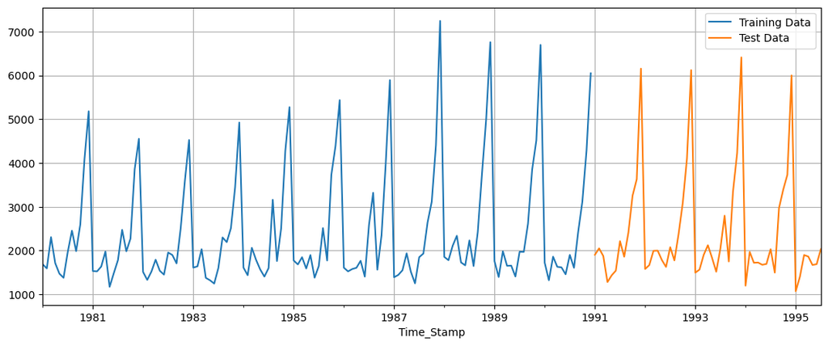

```python
# Visualize the training and test dataset
df_train["Sparkling"].plot(figsize = (13, 5))
df_test["Sparkling"].plot(figsize = (13, 5))
plt.grid()
plt.legend(["Training Data", "Test Data"])
plt.show()
```

## Model Building

### Linear Regression Model

- For this particular linear regression, we are going to regress the 'Sparkling' variable against the order of the occurrence.
- For this we need to modify our training data before fitting it into a linear regression.

```python
train_time = [i + 1 for i in range(len(df_train))]
test_time = [i + 1 for i in range(len(df_test))]
print("Training Time instance", "\n", train_time)
print("Test Time instance", "\n", test_time)
```

```
Training Time instance
 [1, 2, 3, 4, 5, 6, 7, 8, 9, 10, 11, 12, 13, 14, 15, 16, 17, 18, 19, 20, 21, 22, 23, 24, 25, 26, 27, 28, 29, 30, 31, 32, 33, 34, 35, 36, 37, 38, 39, 40, 41, 42, 43, 44, 45, 46, 47, 48, 49, 50, 51, 52, 53, 54, 55, 56, 57, 58, 59, 60, 61, 62, 63, 64, 65, 66, 67, 68, 69, 70, 71, 72, 73, 74, 75, 76, 77,…
Test Time instance
 [1, 2, 3, 4, 5, 6, 7, 8, 9, 10, 11, 12, 13, 14, 15, 16, 17, 18, 19, 20, 21, 22, 23, 24, 25, 26, 27, 28, 29, 30, 31, 32, 33, 34, 35, 36, 37, 38, 39, 40, 41, 42, 43, 44, 45, 46, 47, 48, 49, 50, 51, 52, 53, 54, 55]
```

```python
# Create a copy of the train and test dataset
LinearRegression_train = df_train.copy()
LinearRegression_test = df_test.copy()
```

```python
# Add the train_time and test_time into the copied version of the dataset
LinearRegression_train["time"] = train_time
LinearRegression_test["time"] = test_time

print("First few rows of Training Data", "\n", LinearRegression_train.head(), "\n")
print("Last few rows of Training Data", "\n", LinearRegression_train.tail(), "\n")
print("First few rows of Test Data", "\n", LinearRegression_test.head(), "\n")
print("Last few rows of Test Data", "\n", LinearRegression_test.tail(), "\n")
```

```
First few rows of Training Data
             Sparkling  time
Time_Stamp
1980-01-31       1686     1
1980-02-29       1591     2
1980-03-31       2304     3
1980-04-30       1712     4
1980-05-31       1471     5

Last few rows of Training Data
             Sparkling  time
Time_Stamp
1990-08-31       1605   128
1990-09-30       2424   129
1990-10-31       3116   130
1990-11-30       4286   131
1990-12-31       6047   132

First few rows of Test Data
             Sparkling  time
Time_Stamp
1991-01-31       1902     1
1991-02-28       2049     2
1991-03-31       1874     3
1991-04-30       1279     4
1991-05-31       1432     5

Last few rows of Test Data
             Sparkling  time
Time_Stamp
1995-03-31       1897    51
1995-04-30       1862    52
1995-05-31       1670    53
1995-06-30       1688    54
1995-07-31       2031    55
```

```python
# Build the linear regression
lr = LinearRegression()
LinearRegression_train["Sparkling"].values
lr.fit(LinearRegression_train[["time"]], LinearRegression_train["Sparkling"].values)
```

```
LinearRegression()
```

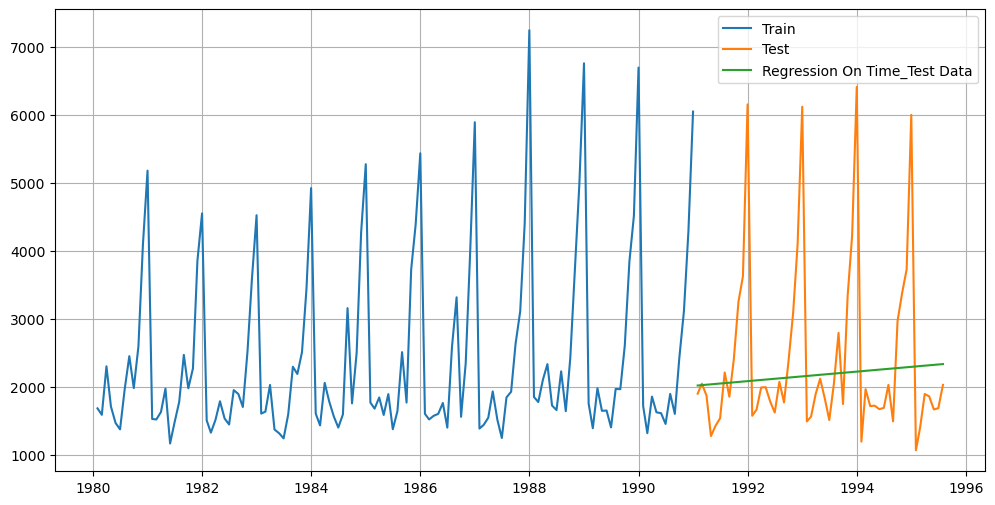

```python
test_prediction_model = lr.predict(LinearRegression_test[["time"]])
LinearRegression_test["RegOnTime"] = test_prediction_model

plt.figure(figsize = (12, 6))
plt.plot(df_train["Sparkling"], label = "Train")
plt.plot(df_test["Sparkling"], label = "Test")
plt.plot(LinearRegression_test["RegOnTime"], label = "Regression On Time_Test Data")
plt.legend(loc = "best")
plt.grid();
```

```python
# Model Evaluation
rmse_model_test = metrics.mean_squared_error(df_test["Sparkling"], test_prediction_model, squared = False)
print("For RegressionOnTime forecast on the Test Data, RMSE is %3.3f" %(rmse_model_test))
```

```
For RegressionOnTime forecast on the Test Data, RMSE is 1294.440
```

```python
resultsDf = pd.DataFrame({"Test RMSE": [rmse_model_test]}, index = ["RegressionOnTime"])
resultsDf
```

|  | Test RMSE |
| --- | --- |
| RegressionOnTime | 1294.440103 |

### Naive Approach Model

- For this particular naive model, we say that the prediction for tomorrow is the same as today and the prediction for day after tomorrow is tomorrow and since the prediction of tomorrow is same as today, therefore the prediction for day after tomorrow is also today.

```python
# Create a copy of the train and test dataset
NaiveModel_train = df_train.copy()
NaiveModel_test = df_test.copy()
```

```python
# Check the shape of the dataset
print(f"In the training dataset, there are {NaiveModel_train.shape[0]} rows and {NaiveModel_train.shape[1]} column.")
print(f"In the test dataset, there are {NaiveModel_test.shape[0]} rows and {NaiveModel_test.shape[1]} column.")
```

```
In the training dataset, there are 132 rows and 1 column.
In the test dataset, there are 55 rows and 1 column.
```

```python
# Check the first few rows in the test set
NaiveModel_test.head()
```

| Time_Stamp | Sparkling |
| --- | --- |
| 1991-01-31 | 1902 |
| 1991-02-28 | 2049 |
| 1991-03-31 | 1874 |
| 1991-04-30 | 1279 |
| 1991-05-31 | 1432 |

```python
# Replace test data with the last data on the training set
NaiveModel_test["naive"] = np.asarray(df_train["Sparkling"])[len(np.asarray(df_train["Sparkling"])) - 1]
NaiveModel_test["naive"].head()
```

```
Time_Stamp
1991-01-31    6047
1991-02-28    6047
1991-03-31    6047
1991-04-30    6047
1991-05-31    6047
Name: naive, dtype: int64
```

```python
# Check the first few rows in the test set
NaiveModel_test.head()
```

| Time_Stamp | Sparkling | naive |
| --- | --- | --- |
| 1991-01-31 | 1902 | 6047 |
| 1991-02-28 | 2049 | 6047 |
| 1991-03-31 | 1874 | 6047 |
| 1991-04-30 | 1279 | 6047 |
| 1991-05-31 | 1432 | 6047 |

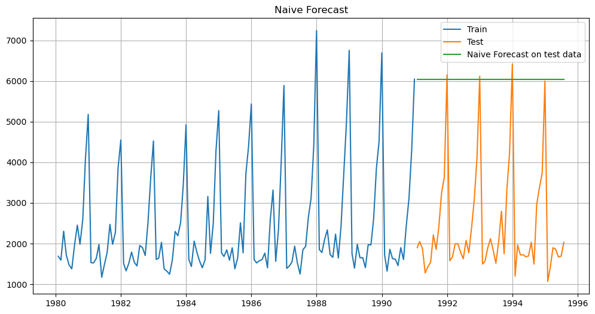

```python
# Visualize the forecast
plt.figure(figsize=(12, 6))
plt.plot(NaiveModel_train["Sparkling"], label = "Train")
plt.plot(df_test["Sparkling"],label = "Test")
plt.plot(NaiveModel_test["naive"], label = "Naive Forecast on test data")
plt.legend(loc = "best")
plt.title("Naive Forecast")
plt.grid();
```

```python
# Model Evaluation
rmse_model_test = metrics.mean_squared_error(df_test["Sparkling"], NaiveModel_test["naive"], squared = False)
print("For Naive On Time Forecast on the Test Data, RMSE is %3.3f" %(rmse_model_test))
```

```
For Naive On Time Forecast on the Test Data, RMSE is 3864.279
```

```python
resultsDfN = pd.DataFrame({'Test RMSE': [rmse_model_test]}, index = ["Naive on Time"])
resultsDf = pd.concat([resultsDf, resultsDfN])
resultsDf
```

|  | Test RMSE |
| --- | --- |
| RegressionOnTime | 1294.440103 |
| Naive on Time | 3864.279352 |

### Simple Average Model

- For this particular simple average method, we will forecast by using the average of the training values.

```python
# Create a copy of the train and test dataset
SimpleAverage_train = df_train.copy()
SimpleAverage_test = df_test.copy()
```

```python
# Average of training values
SimpleAverage_test["mean forecast"]= df_train["Sparkling"].mean()
SimpleAverage_test.head()
```

| Time_Stamp | Sparkling | mean forecast |
| --- | --- | --- |
| 1991-01-31 | 1902 | 2403.780303 |
| 1991-02-28 | 2049 | 2403.780303 |
| 1991-03-31 | 1874 | 2403.780303 |
| 1991-04-30 | 1279 | 2403.780303 |
| 1991-05-31 | 1432 | 2403.780303 |

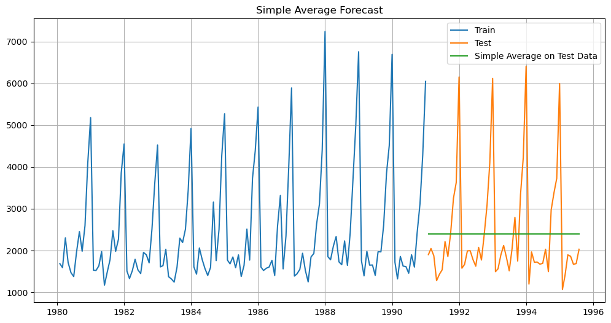

```python
# Visualize the forecast
plt.figure(figsize = (12, 6))
plt.plot(df_train["Sparkling"], label = "Train")
plt.plot(df_test["Sparkling"], label = "Test")
plt.plot(SimpleAverage_test["mean forecast"], label = "Simple Average on Test Data")
plt.legend(loc = "best")
plt.title("Simple Average Forecast")
plt.grid();
```

```python
# Model Evaluation
rmse_model_test = metrics.mean_squared_error(df_test["Sparkling"], SimpleAverage_test["mean forecast"], squared = False)
print("For Simple Average Forecast on Test Data, RMSE is %3.3f" %(rmse_model_test))
```

```
For Simple Average Forecast on Test Data, RMSE is 1275.082
```

```python
resultsDfSES = pd.DataFrame({'Test RMSE':  [rmse_model_test]}, index = ["Simple Average"])
resultsDf = pd.concat([resultsDf, resultsDfSES])
resultsDf
```

|  | Test RMSE |
| --- | --- |
| RegressionOnTime | 1294.440103 |
| Naive on Time | 3864.279352 |
| Simple Average | 1275.081804 |

### Simple Exponential Smoothing Model

```python
# Creating the copy of train and test dataset
SES_train = df_train.copy()
SES_test = df_test.copy()
```

```python
# Build the simple exponential smoothing model
model_SES = SimpleExpSmoothing(SES_train["Sparkling"])
```

```python
model_SES_autofit = model_SES.fit(optimized = True)
```

```python
model_SES_autofit.params
```

```
{'smoothing_level': 0.03953488372093023,
 'smoothing_trend': nan,
 'smoothing_seasonal': nan,
 'damping_trend': nan,
 'initial_level': 1686.0,
 'initial_trend': nan,
 'initial_seasons': array([], dtype=float64),
 'use_boxcox': False,
 'lamda': None,
 'remove_bias': False}
```

```python
SES_test["predict"] = model_SES_autofit.forecast(steps = len(df_test))
```

```python
SES_test.head()
```

| Time_Stamp | Sparkling | predict |
| --- | --- | --- |
| 1991-01-31 | 1902 | 2676.676366 |
| 1991-02-28 | 2049 | 2676.676366 |
| 1991-03-31 | 1874 | 2676.676366 |
| 1991-04-30 | 1279 | 2676.676366 |
| 1991-05-31 | 1432 | 2676.676366 |

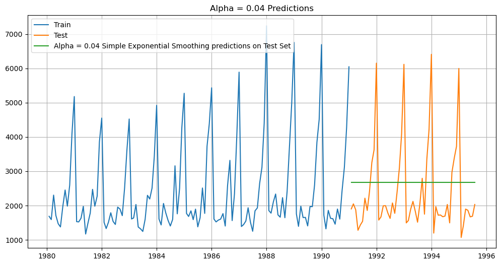

```python
# Plotting on both the Training and Test data

plt.figure(figsize = (12, 6))
plt.plot(SES_train["Sparkling"], label = "Train")
plt.plot(SES_test["Sparkling"], label = "Test")

plt.plot(SES_test["predict"], label = "Alpha = 0.04 Simple Exponential Smoothing predictions on Test Set")

plt.legend(loc = "best")
plt.grid()
plt.title("Alpha = 0.04 Predictions");
```

#### Model Evaluation for 𝛼 = 0.04 : Simple Exponential Smoothing

```python
# Model Evaluation
rmse_model_test = metrics.mean_squared_error(SES_test["Sparkling"], SES_test["predict"], squared = False)
print("For Alpha = 0.04 SES Model on Test Data, RMSE is %3.3f" %(rmse_model_test))
```

```
For Alpha = 0.04 SES Model on Test Data, RMSE is 1304.927
```

```python
resultsDf_1 = pd.DataFrame({'Test RMSE': [rmse_model_test]}, index = ["Alpha = 0.04, SimpleExponentialSmoothing"])
resultsDf = pd.concat([resultsDf, resultsDf_1])
resultsDf
```

|  | Test RMSE |
| --- | --- |
| RegressionOnTime | 1294.440103 |
| Naive on Time | 3864.279352 |
| Simple Average | 1275.081804 |
| Alpha = 0.04, SimpleExponentialSmoothing | 1304.927405 |

#### Setting Different Alpha Values

- Remember, the higher the alpha value more weightage is given to the more recent observation. That means, what happened recently will happen again.

We will run a loop with different alpha values to understand which particular value works best for alpha on the test set.

```python
# First we will define an empty dataframe to store our values from the loop
resultsDf_a = pd.DataFrame({'Alpha Values': [], "Train RMSE": [], "Test RMSE": []})
resultsDf_a
```

|  | Alpha Values | Train RMSE | Test RMSE |
| --- | --- | --- | --- |

```python
for i in np.arange(0.3, 1, 0.1):
    model_SES_alpha_i = model_SES.fit(smoothing_level = i, optimized = False, use_brute = True)
    SES_train["predict", i] = model_SES_alpha_i.fittedvalues
    SES_test["predict", i] = model_SES_alpha_i.forecast(steps = 55)

    rmse_model5_train_i = metrics.mean_squared_error(SES_train["Sparkling"], SES_train["predict", i], squared = False)

    rmse_model5_test_i = metrics.mean_squared_error(SES_test["Sparkling"], SES_test["predict", i], squared = False)

    resultsDf_temp = pd.DataFrame({"Alpha Values": i, "Train RMSE": rmse_model5_train_i, "Test RMSE": rmse_model5_test_i},
                                 index = [""])

    resultsDf_a = pd.concat([resultsDf_a, resultsDf_temp])
```

```python
resultsDf_a.sort_values(by = ["Test RMSE"], ascending = True)
```

|  | Alpha Values | Train RMSE | Test RMSE |
| --- | --- | --- | --- |
|  | 0.3 | 1359.511747 | 1935.507132 |
|  | 0.4 | 1352.588879 | 2311.919615 |
|  | 0.5 | 1344.004369 | 2666.351413 |
|  | 0.6 | 1338.805381 | 2979.204388 |
|  | 0.7 | 1338.844308 | 3249.944092 |
|  | 0.8 | 1344.462091 | 3483.801006 |
|  | 0.9 | 1355.723518 | 3686.794285 |

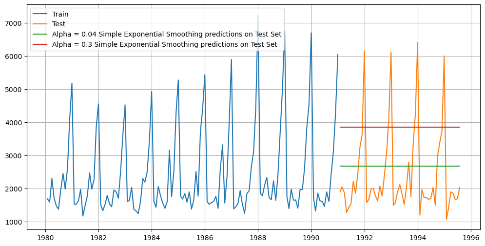

```python
# Plotting on both the Training and Test data
plt.figure(figsize = (12, 6))
plt.plot(SES_train["Sparkling"], label = "Train")
plt.plot(SES_test["Sparkling"], label = "Test")

plt.plot(SES_test["predict"], label = "Alpha = 0.04 Simple Exponential Smoothing predictions on Test Set")

plt.plot(SES_test["predict", 0.3], label = "Alpha = 0.3 Simple Exponential Smoothing predictions on Test Set")

plt.legend(loc='best')
plt.grid();
```

```python
resultsDf_2 = pd.DataFrame({"Test RMSE": [resultsDf_a.sort_values(by = ["Test RMSE"], ascending = True).values[0][2]]}
                           , index = ["Alpha = 0.3, SimpleExponentialSmoothing"])

resultsDf = pd.concat([resultsDf, resultsDf_2])
resultsDf
```

|  | Test RMSE |
| --- | --- |
| RegressionOnTime | 1294.440103 |
| Naive on Time | 3864.279352 |
| Simple Average | 1275.081804 |
| Alpha = 0.04, SimpleExponentialSmoothing | 1304.927405 |
| Alpha = 0.3, SimpleExponentialSmoothing | 1935.507132 |

### Double Exponential Smoothing (Holt's Model)

Two parameters 𝛼 and 𝛽 are estimated in this model. Level and Trend are accounted for in this model.

```python
# Creating the copy of train and test dataset
DES_train = df_train.copy()
DES_test = df_test.copy()
```

```python
# Build the Holt's model
model_DES =  Holt(DES_train["Sparkling"])
```

```python
model_DES_autofit = model_DES.fit()
```

```python
model_DES_autofit.params
```

```
{'smoothing_level': 0.6885714285714285,
 'smoothing_trend': 9.999999999999999e-05,
 'smoothing_seasonal': nan,
 'damping_trend': nan,
 'initial_level': 1686.0,
 'initial_trend': -95.0,
 'initial_seasons': array([], dtype=float64),
 'use_boxcox': False,
 'lamda': None,
 'remove_bias': False}
```

```python
DES_test.shape
```

```
(55, 1)
```

```python
# Prediction on the test data
DES_test["auto_predict"] = model_DES_autofit.forecast(steps = 55)
DES_test.head()
```

| Time_Stamp | Sparkling | auto_predict |
| --- | --- | --- |
| 1991-01-31 | 1902 | 5221.278699 |
| 1991-02-28 | 2049 | 5127.886554 |
| 1991-03-31 | 1874 | 5034.494409 |
| 1991-04-30 | 1279 | 4941.102264 |
| 1991-05-31 | 1432 | 4847.710119 |

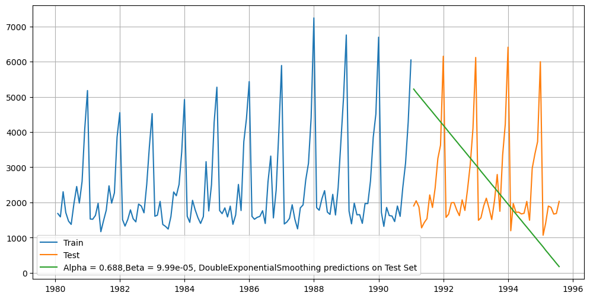

```python
# Plotting on both the Training and Test using autofit

plt.figure(figsize = (12, 6))
plt.plot(DES_train["Sparkling"], label = "Train")
plt.plot(DES_test["Sparkling"], label = "Test")

plt.plot(DES_test["auto_predict"], label = "Alpha = 0.688,Beta = 9.99e-05, DoubleExponentialSmoothing predictions on Test Set")

plt.legend(loc = "best")
plt.grid();
```

```python
# Model Evaluation
rmse_model_test = metrics.mean_squared_error(DES_test["Sparkling"], DES_test["auto_predict"], squared = False)
print("For Alpha = 0.688, Beta = 0.00009, DoubleExponentialSmoothing predictions on Test Data, RMSE is %3.3f" %(rmse_model_test))
```

```
For Alpha = 0.688, Beta = 0.00009, DoubleExponentialSmoothing predictions on Test Data, RMSE is 2007.239
```

```python
resultsDf_DES = pd.DataFrame({"Test RMSE": [rmse_model_test]}
                           , index = ["Alpha=0.688, Beta=0.00009, DoubleExponentialSmoothing"])

resultsDf = pd.concat([resultsDf, resultsDf_DES])
resultsDf
```

|  | Test RMSE |
| --- | --- |
| RegressionOnTime | 1294.440103 |
| Naive on Time | 3864.279352 |
| Simple Average | 1275.081804 |
| Alpha = 0.04, SimpleExponentialSmoothing | 1304.927405 |
| Alpha = 0.3, SimpleExponentialSmoothing | 1935.507132 |
| Alpha=0.688, Beta=0.00009, DoubleExponentialSmoothing | 2007.238526 |

#### Setting Different Alpha Values

```python
# First we will define an empty dataframe to store our values from the loop
resultsDf_b = pd.DataFrame({"Alpha Values": [], "Beta Values": [], "Train RMSE": [], "Test RMSE": []})
resultsDf_b
```

|  | Alpha Values | Beta Values | Train RMSE | Test RMSE |
| --- | --- | --- | --- | --- |

```python
len(df_test)
```

```
55
```

```python
for i in np.arange(0.3, 1.1, 0.1):
    for j in np.arange(0.3, 1.1, 0.1):
        model_DES_alpha_i_j = model_DES.fit(smoothing_level = i, smoothing_trend = j, optimized = False, use_brute = True)
        DES_train["predict", i, j] = model_DES_alpha_i_j.fittedvalues
        DES_test["predict", i, j] = model_DES_alpha_i_j.forecast(steps = 55)

        rmse_model_train = metrics.mean_squared_error(DES_train["Sparkling"], DES_train["predict", i, j], squared = False)

        rmse_model_test = metrics.mean_squared_error(DES_test["Sparkling"], DES_test["predict", i, j], squared = False)

        resultsDf_temp = pd.DataFrame({"Alpha Values": i, "Beta Values": j, "Train RMSE": rmse_model_train,
                                       "Test RMSE": rmse_model_test}, index = [""])

        resultsDf_b = pd.concat([resultsDf_b, resultsDf_temp])
```

```python
resultsDf_b.sort_values(by = ["Test RMSE"]).head()
```

|  | Alpha Values | Beta Values | Train RMSE | Test RMSE |
| --- | --- | --- | --- | --- |
|  | 0.3 | 0.3 | 1592.292788 | 18259.110704 |
|  | 0.4 | 0.3 | 1569.338606 | 23878.496940 |
|  | 0.3 | 0.4 | 1682.573828 | 26069.841401 |
|  | 0.5 | 0.3 | 1530.575845 | 27095.532414 |
|  | 0.6 | 0.3 | 1506.449870 | 29070.722592 |

```python
DES_test.columns
```

```
Index([                                        'Sparkling',
                                            'auto_predict',
                                     ('predict', 0.3, 0.3),
                                     ('predict', 0.3, 0.4),
                                     ('predict', 0.3, 0.5),
                      ('predict', 0.3, 0.6000000000000001),
                      ('predict', 0.3, 0.7000000000000002),
                      ('predict', 0.3, 0.8000000000000003),
                      ('predict', 0.3, 0.9000000000000001),
                      ('predict', 0.3, 1.0000000000000002),
                                     ('predict', 0.4, 0.3),
                                     ('predict', 0.4, 0.4),
                                     ('predict', 0.4, 0.5),
                      ('predict', 0.4, 0.6000000000000001),
                      ('predict', 0.4, 0.7000000000000002),
                      ('predict', 0.4, 0.8000000000000003),
                      ('predict', 0.4, 0.9000000000000001),
                      ('predict', 0.4, 1.0000000000000002),
                                     ('predict', 0.5, 0.3),
                                     ('predict', 0.5, 0.4),
                                     ('predict', 0.5, 0.5),
                      ('predict', 0.5, 0.6000000000000001),
                      ('predict', 0.5, 0.7000000000000002),
                      ('predict', 0.5, 0.8000000000000003),
                      ('predict', 0.5, 0.9000000000000001),
                      ('predict', 0.5, 1.0000000000000002),
                      ('predict', 0.6000000000000001, 0.3),
                      ('predict', 0.6000000000000001, 0.4),
                      ('predict', 0.6000000000000001, 0.5),
       ('predict', 0.6000000000000001, 0.6000000000000001),
       ('predict', 0.6000000000000001, 0.7000000000000002),
       ('predict', 0.6000000000000001, 0.8000000000000003),
       ('predict', 0.6000000000000001, 0.9000000000000001),
       ('predict', 0.6000000000000001, 1.0000000000000002),
                      ('predict', 0.7000000000000002, 0.3),
                      ('predict', 0.7000000000000002, 0.4),
                      ('predict', 0.7000000000000002, 0.5),
       ('predict', 0.7000000000000002, 0.6000000000000001),
       ('predict', 0.7000000000000002, 0.7000000000000002),
       ('predict', 0.7000000000000002, 0.8000000000000003),
```

[output cut: 12 more lines]

```
                      ('predict', 0.9000000000000001, 0.5),
       ('predict', 0.9000000000000001, 0.6000000000000001),
       ('predict', 0.9000000000000001, 0.7000000000000002),
       ('predict', 0.9000000000000001, 0.8000000000000003),
       ('predict', 0.9000000000000001, 0.9000000000000001),
       ('predict', 0.9000000000000001, 1.0000000000000002),
                      ('predict', 1.0000000000000002, 0.3),
                      ('predict', 1.0000000000000002, 0.4),
                      ('predict', 1.0000000000000002, 0.5),
       ('predict', 1.0000000000000002, 0.6000000000000001),
       ('predict', 1.0000000000000002, 0.7000000000000002),
       ('predict', 1.0000000000000002, 0.8000000000000003),
       ('predict', 1.0000000000000002, 0.9000000000000001),
       ('predict', 1.0000000000000002, 1.0000000000000002)],
      dtype='object')
```

```python
resultsDf_3 = pd.DataFrame({"Test RMSE": [resultsDf_b.sort_values(by = ["Test RMSE"]).values[0][3]]}
                           , index = ["Alpha=0.3, Beta=0.3, DoubleExponentialSmoothing"])

resultsDf = pd.concat([resultsDf, resultsDf_3])
resultsDf
```

|  | Test RMSE |
| --- | --- |
| RegressionOnTime | 1294.440103 |
| Naive on Time | 3864.279352 |
| Simple Average | 1275.081804 |
| Alpha = 0.04, SimpleExponentialSmoothing | 1304.927405 |
| Alpha = 0.3, SimpleExponentialSmoothing | 1935.507132 |
| Alpha=0.688, Beta=0.00009, DoubleExponentialSmoothing | 2007.238526 |
| Alpha=0.3, Beta=0.3, DoubleExponentialSmoothing | 18259.110704 |

### Triple Exponential Smoothing (Holt - Winter's Model)

Three parameters 𝛼 , 𝛽 and 𝛾 are estimated in this model. Level, Trend and Seasonality are accounted for in this model.

```python
# Creating the copy of train and test dataset
TES_train = df_train.copy()
TES_test = df_test.copy()
```

```python
# Buld the Holt - Winter's model
model_TES = ExponentialSmoothing(TES_train["Sparkling"], trend = "additive", seasonal = "multiplicative", freq = "M")
```

```python
model_TES_autofit = model_TES.fit()
```

```python
model_TES_autofit.params
```

```
{'smoothing_level': 0.11133818361298699,
 'smoothing_trend': 0.049505131019509915,
 'smoothing_seasonal': 0.3620795793580111,
 'damping_trend': nan,
 'initial_level': 2356.4967888704355,
 'initial_trend': -10.187944726007238,
 'initial_seasons': array([0.71296382, 0.68242226, 0.90755008, 0.80515228, 0.65597218,
        0.65414505, 0.88617935, 1.13345121, 0.92046306, 1.21337874,
        1.87340336, 2.37811768]),
 'use_boxcox': False,
 'lamda': None,
 'remove_bias': False}
```

```python
# Prediction on test set
TES_test["auto_predict"] = model_TES_autofit.forecast(steps = len(df_test))
TES_test.head()
```

| Time_Stamp | Sparkling | auto_predict |
| --- | --- | --- |
| 1991-01-31 | 1902 | 1587.497468 |
| 1991-02-28 | 2049 | 1356.394925 |
| 1991-03-31 | 1874 | 1762.929755 |
| 1991-04-30 | 1279 | 1656.165933 |
| 1991-05-31 | 1432 | 1542.002730 |

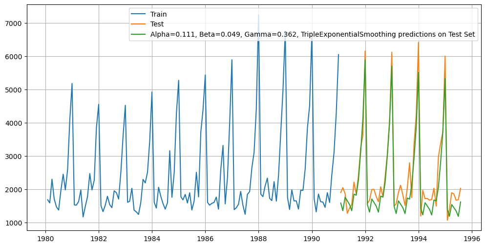

```python
# Plotting on both the Training and Test using autofit

plt.figure(figsize = (12, 6))
plt.plot(TES_train["Sparkling"], label = "Train")
plt.plot(TES_test["Sparkling"], label = "Test")

plt.plot(TES_test["auto_predict"], label = "Alpha=0.111, Beta=0.049, Gamma=0.362, TripleExponentialSmoothing predictions on Test Set")

plt.legend(loc = "best")
plt.grid();
```

```python
# Model Evaluation
rmse_model_test = metrics.mean_squared_error(TES_test["Sparkling"], TES_test["auto_predict"], squared = False)
print("Alpha=0.111, Beta=0.049, Gamma=0.362, TripleExponentialSmoothing predictions on Test Set, RMSE is %3.3f" %(rmse_model_test))
```

```
Alpha=0.111, Beta=0.049, Gamma=0.362, TripleExponentialSmoothing predictions on Test Set, RMSE is 404.287
```

```python
resultsDf_TES = pd.DataFrame({"Test RMSE": [rmse_model_test]}
                           , index = ["Alpha=0.111, Beta=0.049, Gamma=0.362, TripleExponentialSmoothing"])

resultsDf = pd.concat([resultsDf, resultsDf_TES])
resultsDf
```

|  | Test RMSE |
| --- | --- |
| RegressionOnTime | 1294.440103 |
| Naive on Time | 3864.279352 |
| Simple Average | 1275.081804 |
| Alpha = 0.04, SimpleExponentialSmoothing | 1304.927405 |
| Alpha = 0.3, SimpleExponentialSmoothing | 1935.507132 |
| Alpha=0.688, Beta=0.00009, DoubleExponentialSmoothing | 2007.238526 |
| Alpha=0.3, Beta=0.3, DoubleExponentialSmoothing | 18259.110704 |
| Alpha=0.111, Beta=0.049, Gamma=0.362, TripleExponentialSmoothing | 404.286809 |

#### Setting Different Alpha Values

```python
# First we will define an empty dataframe to store our values from the loop
resultsDf_c = pd.DataFrame({"Alpha Values": [], "Beta Values": [], "Gamma Values": [], "Train RMSE": [], "Test RMSE": []})
resultsDf_c
```

|  | Alpha Values | Beta Values | Gamma Values | Train RMSE | Test RMSE |
| --- | --- | --- | --- | --- | --- |

```python
for i in np.arange(0.3, 1.1, 0.1):
    for j in np.arange(0.3, 1.1, 0.1):
        for k in np.arange(0.3, 1.1, 0.1):
            model_TES_alpha_i_j_k = model_TES.fit(smoothing_level = i, smoothing_trend = j, smoothing_seasonal = k, optimized = False, use_brute = True)
            TES_train["predict", i, j, k] = model_TES_alpha_i_j_k.fittedvalues
            TES_test["predict", i, j, k] = model_TES_alpha_i_j_k.forecast(steps = 55)

            rmse_model_train = metrics.mean_squared_error(TES_train["Sparkling"], TES_train["predict", i, j, k], squared = False)

            rmse_model_test = metrics.mean_squared_error(TES_test["Sparkling"], TES_test["predict", i, j, k], squared = False)

            resultsDf_temp = pd.DataFrame({"Alpha Values": i, "Beta Values": j, "Gamma Values": k,
                                              "Train RMSE": rmse_model_train, "Test RMSE": rmse_model_test}, index = [""])

            resultsDf_c = pd.concat([resultsDf_c, resultsDf_temp])
```

```python
resultsDf_c.sort_values(by = ["Test RMSE"]).head()
```

|  | Alpha Values | Beta Values | Gamma Values | Train RMSE | Test RMSE |
| --- | --- | --- | --- | --- | --- |
|  | 0.3 | 0.3 | 0.3 | 397.797318 | 361.397300 |
|  | 0.3 | 0.5 | 0.4 | 452.801424 | 512.542557 |
|  | 0.8 | 1.0 | 0.3 | 790.740655 | 580.266110 |
|  | 0.4 | 0.3 | 0.5 | 448.661280 | 592.153132 |
|  | 0.3 | 0.4 | 0.3 | 415.172097 | 605.110479 |

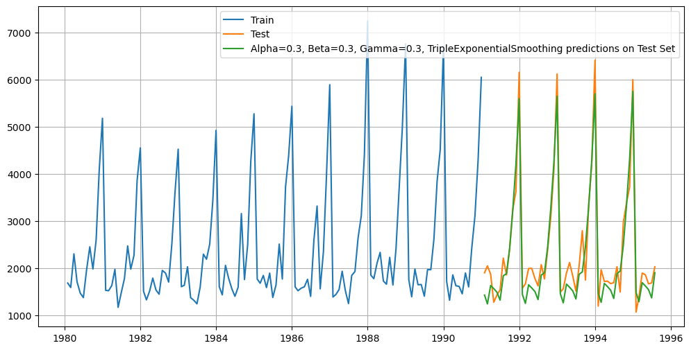

```python
# Plotting on both the Training and Test data using brute force alpha, beta and gamma determination
plt.figure(figsize = (12, 6))
plt.plot(TES_train["Sparkling"], label = "Train")
plt.plot(TES_test["Sparkling"], label = "Test")

#The value of alpha and beta is taken like that by python
plt.plot(TES_test["predict", 0.3, 0.3, 0.3], label = "Alpha=0.3, Beta=0.3, Gamma=0.3, TripleExponentialSmoothing predictions on Test Set")

plt.legend(loc = "best")
plt.grid();
```

```python
resultsDf_2 = pd.DataFrame({"Test RMSE": [resultsDf_c.sort_values(by = ["Test RMSE"]).values[0][4]]}
                           , index = ["Alpha=0.3, Beta=0.3, Gamma=0.3, TripleExponentialSmoothing"])

resultsDf = pd.concat([resultsDf, resultsDf_2])
resultsDf
```

|  | Test RMSE |
| --- | --- |
| RegressionOnTime | 1294.440103 |
| Naive on Time | 3864.279352 |
| Simple Average | 1275.081804 |
| Alpha = 0.04, SimpleExponentialSmoothing | 1304.927405 |
| Alpha = 0.3, SimpleExponentialSmoothing | 1935.507132 |
| Alpha=0.688, Beta=0.00009, DoubleExponentialSmoothing | 2007.238526 |
| Alpha=0.3, Beta=0.3, DoubleExponentialSmoothing | 18259.110704 |
| Alpha=0.111, Beta=0.049, Gamma=0.362, TripleExponentialSmoothing | 404.286809 |
| Alpha=0.3, Beta=0.3, Gamma=0.3, TripleExponentialSmoothing | 361.397300 |

```python
resultsDf1 = resultsDf.sort_values(by = ["Test RMSE"])
resultsDf1
```

|  | Test RMSE |
| --- | --- |
| Alpha=0.3, Beta=0.3, Gamma=0.3, TripleExponentialSmoothing | 361.397300 |
| Alpha=0.111, Beta=0.049, Gamma=0.362, TripleExponentialSmoothing | 404.286809 |
| Simple Average | 1275.081804 |
| RegressionOnTime | 1294.440103 |
| Alpha = 0.04, SimpleExponentialSmoothing | 1304.927405 |
| Alpha = 0.3, SimpleExponentialSmoothing | 1935.507132 |
| Alpha=0.688, Beta=0.00009, DoubleExponentialSmoothing | 2007.238526 |
| Naive on Time | 3864.279352 |
| Alpha=0.3, Beta=0.3, DoubleExponentialSmoothing | 18259.110704 |

### Checking for Stationarity

Let's check for the stationarity of the data on which the model is being built on using appropriate statistical tests and also mention the hypothesis for the statistical test. If the data is found to be non-stationary, take appropriate steps to make it stationary. Check the new data for stationarity and comment. Note: Stationarity should be checked at alpha = 0.05.

```python
from statsmodels.tsa.stattools import adfuller
def test_stationarity(timeseries):

    #determining roll statistics
    rolmean = timeseries.rolling(window=12).mean()
    rolstd = timeseries.rolling(window=12).std()

    ##plot rolling Statistics:
    orig = plt.plot(timeseries,color='blue',label='Original')
    mean = plt.plot(rolmean, color='red', label='Rolling Mean')
    std = plt.plot(rolstd, color='black', label='Rolling Std')
    plt.legend(loc='best')
    plt.title('Rolling Mean and Standard Deviation')
    plt.show(block=False)

    #Perform Dickey-Fuller Test:
    print('Results of Dickey Fuller Test:')
    dftest = adfuller(timeseries, autolag='AIC')
    dfoutput = pd.Series(dftest[0:4], index=['Test Statistic','p-value','#Lags Used','Number of Observations Used'])
    for key,value in dftest[4].items():
        dfoutput['Critical Value (%s)'%key] = value
    print(dfoutput,'\n')
```

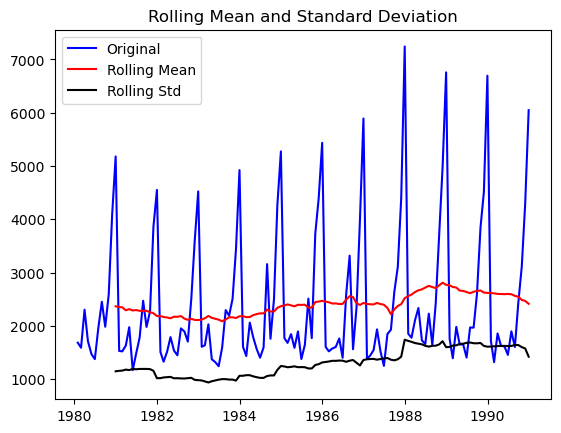

```
Results of Dickey Fuller Test:
Test Statistic                  -1.208926
p-value                          0.669744
#Lags Used                      12.000000
Number of Observations Used    119.000000
Critical Value (1%)             -3.486535
Critical Value (5%)             -2.886151
Critical Value (10%)            -2.579896
dtype: float64
```

```python
test_stationarity(df_train["Sparkling"])
```

**Write the Observations**

H0 : The series is not stationary

Ha: The series is Stationary

- autolag{“AIC”, “BIC”, “t-stat”, None} Method to use when automatically determining the lag length among the values 0, 1, …, maxlag.
- If “AIC” (default) or “BIC”, then the number of lags is chosen to minimize the corresponding information criterion.
- “t-stat” based choice of maxlag. Starts with maxlag and drops a lag until the t-statistic on the last lag length is significant using a 5%-sized t e- t.
- If None, then the number of included lags is set to m- lag.
- The null hypothesis of the Augmented Dickey-Fuller is that there is a unit root, with the alternative that there is no unit root. If the pvalue is above a critical size, then we cannot reject that th unit root.
- **We see that at 5% significant level, the Time Series is non-stationary.**
- Stationary TS allow us to essentially have copies of things which enables us to build appropriate statistical models for forecasting.
- LETS BUILD IT ON DF_TRAIN MODEL

```python
dftest = adfuller(df_train.diff().dropna(), regression = "ct")
print("DF test statistics is %3.3f" %dftest[0])
print("DF test p-value is", dftest[1])
print("DF test p-value is", dftest[2])
```

```
DF test statistics is -7.968
DF test p-value is 8.479210655514579e-11
DF test p-value is 11
```

- We see that $\alpha$ = 0.05 the Time Series is indeed stationary.
- ***The p-value 8.479e-11 is very small, and smaller than 0.05 and thus is a stationary series.***

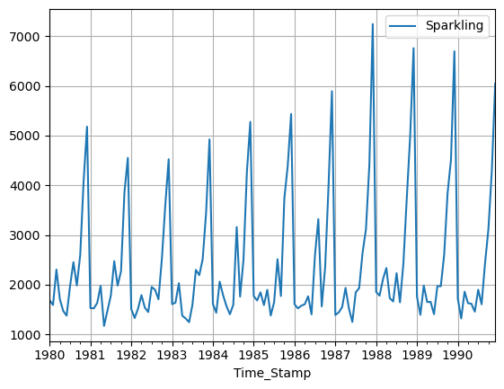

```python
df_train.plot(grid = True);
```

### Automated ARIMA Model based on lowest AIC

Let's build an automated version of the ARIMA model in which the parameters are selected using the lowest Akaike Information Criteria (AIC) on the training data and evaluate this model on the test data using RMSE.

```python
## The following loop helps us in getting a combination of different parameters of p and q in the range of 0 and 4
## We have kept the value of d as 1 as we need to take a difference of the series to make it stationary.

import itertools
p = q = range(0, 4)
d = range(1, 2)
pdq = list(itertools.product(p, d, q))
print("Examples of the parameter combinations for the models")
for i in range(0, len(pdq)):
    print("Model : {}".format(pdq[i]))
```

```
Examples of the parameter combinations for the models
Model : (0, 1, 0)
Model : (0, 1, 1)
Model : (0, 1, 2)
Model : (0, 1, 3)
Model : (1, 1, 0)
Model : (1, 1, 1)
Model : (1, 1, 2)
Model : (1, 1, 3)
Model : (2, 1, 0)
Model : (2, 1, 1)
Model : (2, 1, 2)
Model : (2, 1, 3)
Model : (3, 1, 0)
Model : (3, 1, 1)
Model : (3, 1, 2)
Model : (3, 1, 3)
```

```python
# Creating an empty Dataframe with column names only
ARIMA_AIC = pd.DataFrame(columns=["param", "AIC"])
ARIMA_AIC
```

|  | param | AIC |
| --- | --- | --- |

```python
from statsmodels.tsa.arima.model import ARIMA

for param in pdq: # running a loop within the pdq parameters defined by itertools
    ARIMA_model = ARIMA(df_train["Sparkling"].values, order = param).fit()
    print("ARIMA{} - AIC{}".format(param, ARIMA_model.aic))

    # printing the parameters and the AIC from the fitted models
    ARIMA_AIC1 = pd.DataFrame({"param": param, "AIC": ARIMA_model.aic})
    ARIMA_AIC = pd.concat([ARIMA_AIC, ARIMA_AIC1])

    # concatenating the AIC values and the model parameters to the previously created data frame
    # for easier understanding and sorting of the AIC values
```

```
ARIMA(0, 1, 0) - AIC2267.6630357855465
ARIMA(0, 1, 1) - AIC2263.060015591336
ARIMA(0, 1, 2) - AIC2234.408323131676
ARIMA(0, 1, 3) - AIC2233.9948577474606
ARIMA(1, 1, 0) - AIC2266.6085393190087
ARIMA(1, 1, 1) - AIC2235.755094673378
ARIMA(1, 1, 2) - AIC2234.527200451441
ARIMA(1, 1, 3) - AIC2235.607811807943
ARIMA(2, 1, 0) - AIC2260.365743968086
ARIMA(2, 1, 1) - AIC2233.7776263084434
ARIMA(2, 1, 2) - AIC2213.5092123568647
ARIMA(2, 1, 3) - AIC2232.8839884250565
ARIMA(3, 1, 0) - AIC2257.72337899794
ARIMA(3, 1, 1) - AIC2235.4989261087767
ARIMA(3, 1, 2) - AIC2230.7805912306303
ARIMA(3, 1, 3) - AIC2221.4548970834294
```

```python
# Sort the above AIC values in the ascending order to get the parameters for the minimum AIC value
ARIMA_AIC.sort_values(by = "AIC", ascending = True).head()
```

|  | param | AIC |
| --- | --- | --- |
| 0 | 2 | 2213.509212 |
| 1 | 1 | 2213.509212 |
| 2 | 2 | 2213.509212 |
| 2 | 3 | 2221.454897 |
| 0 | 3 | 2221.454897 |

```python
auto_ARIMA = ARIMA(df_train, order=(2, 1, 2))

results_auto_ARIMA = auto_ARIMA.fit()

print(results_auto_ARIMA.summary())
```

```
                               SARIMAX Results
==============================================================================
Dep. Variable:              Sparkling   No. Observations:                  132
Model:                 ARIMA(2, 1, 2)   Log Likelihood               -1101.755
Date:                Sun, 04 Aug 2024   AIC                           2213.509
Time:                        01:35:36   BIC                           2227.885
Sample:                    01-31-1980   HQIC                          2219.351
                         - 12-31-1990
Covariance Type:                  opg
==============================================================================
                 coef    std err          z      P>|z|      [0.025      0.975]
------------------------------------------------------------------------------
ar.L1          1.3121      0.046     28.782      0.000       1.223       1.401
ar.L2         -0.5593      0.072     -7.741      0.000      -0.701      -0.418
ma.L1         -1.9917      0.109    -18.217      0.000      -2.206      -1.777
ma.L2          0.9999      0.110      9.109      0.000       0.785       1.215
sigma2      1.099e+06   1.99e-07   5.51e+12      0.000     1.1e+06     1.1e+06
===================================================================================
Ljung-Box (L1) (Q):                   0.19   Jarque-Bera (JB):                14.46
Prob(Q):                              0.67   Prob(JB):                         0.00
Heteroskedasticity (H):               2.43   Skew:                             0.61
Prob(H) (two-sided):                  0.00   Kurtosis:                         4.08
===================================================================================

Warnings:
[1] Covariance matrix calculated using the outer product of gradients (complex-step).
[2] Covariance matrix is singular or near-singular, with condition number 8.24e+27. Standard errors may be unstable.
```

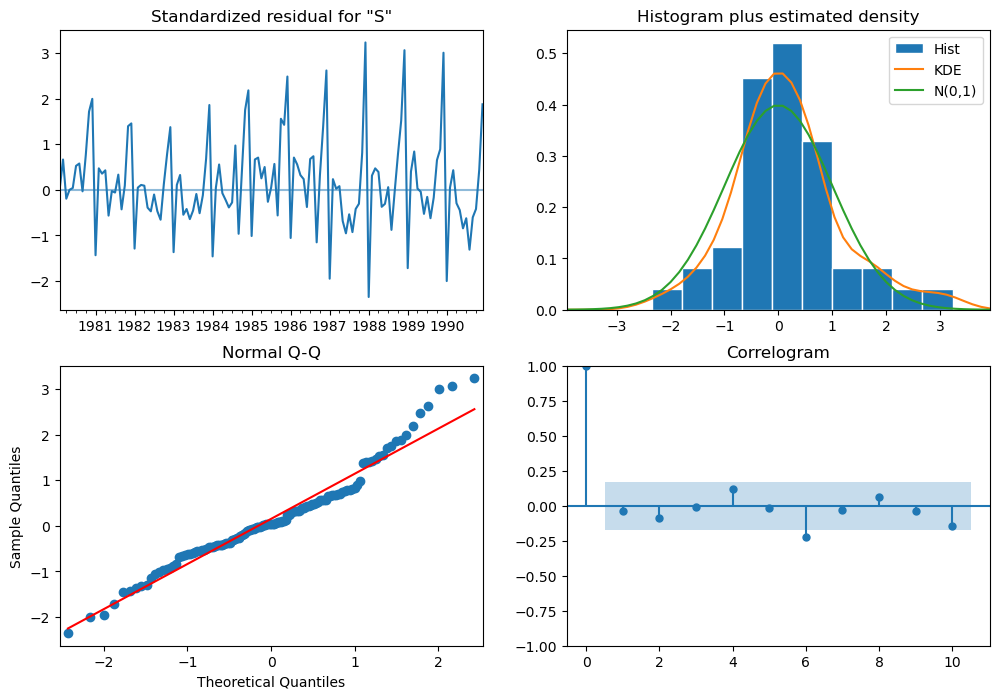

```python
results_auto_ARIMA.plot_diagnostics(figsize = (12, 8));
```

**Predict on the Test Set using this model and evaluate the model.**

```python
predicted_auto_ARIMA = results_auto_ARIMA.forecast(steps = len(df_test))
```

```python
# Mean Absolute Percentage Error (MAPE) - Function Definition
def mean_absolute_percentage_error(y_true, y_pred):
    return np.mean((np.abs(y_true-y_pred))/(y_true))*100

# Importing the mean_squared_error function from sklearn to calculate the RMSE
from sklearn.metrics import mean_squared_error
```

```python
rmse = mean_squared_error(df_test["Sparkling"], predicted_auto_ARIMA, squared = False)
mape = mean_absolute_percentage_error(df_test["Sparkling"], predicted_auto_ARIMA)
print("RMSE:", rmse, "\nMAPE:", mape)
```

```
RMSE: 1299.9800412702375
MAPE: 47.100033405899374
```

```python
from math import sqrt
from sklearn.metrics import mean_squared_error
rmse = sqrt(mean_squared_error(df_test["Sparkling"], predicted_auto_ARIMA))
print(rmse)
```

```
1299.9800412702375
```

```python
resultsDf = pd.DataFrame({"RMSE": rmse, "MAPE":mape}
                           , index = ["ARIMA (2, 1, 2)"])

resultsDf
```

|  | RMSE | MAPE |
| --- | --- | --- |
| ARIMA (2, 1, 2) | 1299.980041 | 47.100033 |

### Automated SARIMA Model based on lowest AIC

Let's build an automated version of the SARIMA model in which the parameters are selected using the lowest Akaike Information Criteria (AIC) on the training data and evaluate this model on the test data using RMSE.

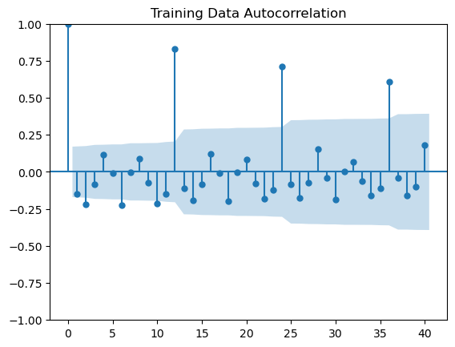

```python
# Let us look at the ACF plot once more to understand the seasonal parameter for the SARIMA model
plot_acf(df_train.diff(), title = "Training Data Autocorrelation", missing = "drop", lags = 40);
```

We see that there can be a seasonality of 12.

```python
# Setting the seasonality as 12 to estimate parametrs using auto SARIMA model.
import itertools
p = q = range(0, 4)
d= range(1, 2)
D = range(0, 1)
pdq = list(itertools.product(p, d, q))
PDQ = [(x[0], x[1], x[2], 12) for x in list(itertools.product(p, D, q))]
print("Examples of the parameter combinations for the Model are")
for i in range(1, len(pdq)):
    print("Model: {}{}".format(pdq[i], PDQ[i]))
```

```
Examples of the parameter combinations for the Model are
Model: (0, 1, 1)(0, 0, 1, 12)
Model: (0, 1, 2)(0, 0, 2, 12)
Model: (0, 1, 3)(0, 0, 3, 12)
Model: (1, 1, 0)(1, 0, 0, 12)
Model: (1, 1, 1)(1, 0, 1, 12)
Model: (1, 1, 2)(1, 0, 2, 12)
Model: (1, 1, 3)(1, 0, 3, 12)
Model: (2, 1, 0)(2, 0, 0, 12)
Model: (2, 1, 1)(2, 0, 1, 12)
Model: (2, 1, 2)(2, 0, 2, 12)
Model: (2, 1, 3)(2, 0, 3, 12)
Model: (3, 1, 0)(3, 0, 0, 12)
Model: (3, 1, 1)(3, 0, 1, 12)
Model: (3, 1, 2)(3, 0, 2, 12)
Model: (3, 1, 3)(3, 0, 3, 12)
```

```python
# Initialize the empty DataFrame
SARIMA_AIC = pd.DataFrame(columns = ["param", "seasonal", "AIC"])
SARIMA_AIC
```

|  | param | seasonal | AIC |
| --- | --- | --- | --- |

```python
import statsmodels.api as sm

for param in pdq:
    for param_seasonal in PDQ:
        SARIMA_model = sm.tsa.statespace.SARIMAX(df_train["Sparkling"].values,
                                            order = param,
                                            seasonal_order = param_seasonal,
                                            enforce_stationarity = False,
                                            enforce_invertibility = False)

        results_SARIMA = SARIMA_model.fit(maxiter = 1000)
        print("SARIMA{}x{} - AIC:{}".format(param, param_seasonal, results_SARIMA.aic))

        # Create a DataFrame for the current iteration
        SARIMA_AIC1 = pd.DataFrame({"param": [param], "seasonal": [param_seasonal], "AIC": [results_SARIMA.aic]})

        # Concatenate the current result with the main DataFrame
        SARIMA_AIC = pd.concat([SARIMA_AIC, SARIMA_AIC1], ignore_index = True)
```

```
SARIMA(0, 1, 0)x(0, 0, 0, 12) - AIC:2251.3597196862966
SARIMA(0, 1, 0)x(0, 0, 1, 12) - AIC:1956.2614616846013
SARIMA(0, 1, 0)x(0, 0, 2, 12) - AIC:1723.153364023626
SARIMA(0, 1, 0)x(0, 0, 3, 12) - AIC:6286.98228520124
SARIMA(0, 1, 0)x(1, 0, 0, 12) - AIC:1837.4366022456677
SARIMA(0, 1, 0)x(1, 0, 1, 12) - AIC:1806.9905301389333
SARIMA(0, 1, 0)x(1, 0, 2, 12) - AIC:1633.2108735791255
SARIMA(0, 1, 0)x(1, 0, 3, 12) - AIC:3076.856299589122
SARIMA(0, 1, 0)x(2, 0, 0, 12) - AIC:1648.3776153470856
SARIMA(0, 1, 0)x(2, 0, 1, 12) - AIC:1647.2054158607627
SARIMA(0, 1, 0)x(2, 0, 2, 12) - AIC:1630.9898053920865
SARIMA(0, 1, 0)x(2, 0, 3, 12) - AIC:6617.185746470539
SARIMA(0, 1, 0)x(3, 0, 0, 12) - AIC:1467.4574095308408
SARIMA(0, 1, 0)x(3, 0, 1, 12) - AIC:1469.1871052625402
SARIMA(0, 1, 0)x(3, 0, 2, 12) - AIC:1471.05945300643
SARIMA(0, 1, 0)x(3, 0, 3, 12) - AIC:3040.0490033133797
SARIMA(0, 1, 1)x(0, 0, 0, 12) - AIC:2230.162907850585
SARIMA(0, 1, 1)x(0, 0, 1, 12) - AIC:1923.7688649566542
SARIMA(0, 1, 1)x(0, 0, 2, 12) - AIC:1692.7089573169826
SARIMA(0, 1, 1)x(0, 0, 3, 12) - AIC:5641.571919903596
SARIMA(0, 1, 1)x(1, 0, 0, 12) - AIC:1797.1795881837984
SARIMA(0, 1, 1)x(1, 0, 1, 12) - AIC:1738.090319376331
SARIMA(0, 1, 1)x(1, 0, 2, 12) - AIC:1570.1509144061731
SARIMA(0, 1, 1)x(1, 0, 3, 12) - AIC:4128.727230596029
SARIMA(0, 1, 1)x(2, 0, 0, 12) - AIC:1605.675195417734
SARIMA(0, 1, 1)x(2, 0, 1, 12) - AIC:1599.2245085300547
SARIMA(0, 1, 1)x(2, 0, 2, 12) - AIC:1570.4018824021878
SARIMA(0, 1, 1)x(2, 0, 3, 12) - AIC:6873.87725151131
SARIMA(0, 1, 1)x(3, 0, 0, 12) - AIC:1428.4607679619842
SARIMA(0, 1, 1)x(3, 0, 1, 12) - AIC:1428.8727985483038
SARIMA(0, 1, 1)x(3, 0, 2, 12) - AIC:1429.5891876651754
SARIMA(0, 1, 1)x(3, 0, 3, 12) - AIC:2859.7332306953613
SARIMA(0, 1, 2)x(0, 0, 0, 12) - AIC:2187.4410101687167
SARIMA(0, 1, 2)x(0, 0, 1, 12) - AIC:1887.9128007200097
SARIMA(0, 1, 2)x(0, 0, 2, 12) - AIC:1659.8789890766202
SARIMA(0, 1, 2)x(0, 0, 3, 12) - AIC:5873.893252770549
SARIMA(0, 1, 2)x(1, 0, 0, 12) - AIC:1790.0326332238851
SARIMA(0, 1, 2)x(1, 0, 1, 12) - AIC:1724.1675071433622
SARIMA(0, 1, 2)x(1, 0, 2, 12) - AIC:1557.1605068198232
SARIMA(0, 1, 2)x(1, 0, 3, 12) - AIC:3561.5191927965147
```

[output cut: 201 more lines]

```
SARIMA(3, 1, 3)x(0, 0, 1, 12) - AIC:1876.9311122148686
SARIMA(3, 1, 3)x(0, 0, 2, 12) - AIC:1643.7829968231856
SARIMA(3, 1, 3)x(0, 0, 3, 12) - AIC:5026.2055171815
SARIMA(3, 1, 3)x(1, 0, 0, 12) - AIC:1754.2703089199865
SARIMA(3, 1, 3)x(1, 0, 1, 12) - AIC:1848.4447719619368
SARIMA(3, 1, 3)x(1, 0, 2, 12) - AIC:1544.405839166189
SARIMA(3, 1, 3)x(1, 0, 3, 12) - AIC:2585.8211889855297
SARIMA(3, 1, 3)x(2, 0, 0, 12) - AIC:1567.1763968603805
SARIMA(3, 1, 3)x(2, 0, 1, 12) - AIC:1561.9915642524156
SARIMA(3, 1, 3)x(2, 0, 2, 12) - AIC:1548.5967875467345
SARIMA(3, 1, 3)x(2, 0, 3, 12) - AIC:6495.514076271302
SARIMA(3, 1, 3)x(3, 0, 0, 12) - AIC:1387.4970222710667
SARIMA(3, 1, 3)x(3, 0, 1, 12) - AIC:1393.1698602211457
SARIMA(3, 1, 3)x(3, 0, 2, 12) - AIC:1396.7584390132909
SARIMA(3, 1, 3)x(3, 0, 3, 12) - AIC:2275.8851788197467
```

```python
SARIMA_AIC.sort_values(by = "AIC", ascending = True)
```

|  | param | seasonal | AIC |
| --- | --- | --- | --- |
| 252 | (3, 1, 3) | (3, 0, 0, 12) | 1387.497022 |
| 220 | (3, 1, 1) | (3, 0, 0, 12) | 1387.788331 |
| 237 | (3, 1, 2) | (3, 0, 1, 12) | 1388.602614 |
| 221 | (3, 1, 1) | (3, 0, 1, 12) | 1388.681484 |
| 222 | (3, 1, 1) | (3, 0, 2, 12) | 1389.195901 |
| ... | ... | ... | ... |
| 219 | (3, 1, 1) | (2, 0, 3, 12) | 6872.694503 |
| 27 | (0, 1, 1) | (2, 0, 3, 12) | 6873.877252 |
| 203 | (3, 1, 0) | (2, 0, 3, 12) | 6943.704554 |
| 139 | (2, 1, 0) | (2, 0, 3, 12) | 6944.368874 |
| 75 | (1, 1, 0) | (2, 0, 3, 12) | 6947.974874 |

256 rows × 3 columns

#### Inference

- Criteria to choose the best fit model is the lowest/minimum AIC value

Here,

- p = non-seasonal AR order = 3,
- d = non-seasonal differencing = 1,
- q = non-seasonal MA order = 3,
- P = seasonal AR order = 3,
- D = seasonal differencing = 0,
- Q = seasonal MA order = 0,
- S = time span of repeating seasonal pattern = 12

```python
# Building SARIMA model with the best parameters
import statsmodels.api as sm

auto_SARIMA = sm.tsa.statespace.SARIMAX(df_train["Sparkling"], order=(3, 1, 3), seasonal_order=(3, 0, 0, 12), enforce_stationarity = False,
                                       enforce_invertibility = False)
results_auto_SARIMA = auto_SARIMA.fit(maxiter = 1000)
print(results_auto_SARIMA.summary())
```

```
                                      SARIMAX Results
===========================================================================================
Dep. Variable:                           Sparkling   No. Observations:                  132
Model:             SARIMAX(3, 1, 3)x(3, 0, [], 12)   Log Likelihood                -683.749
Date:                             Sun, 04 Aug 2024   AIC                           1387.497
Time:                                     01:42:06   BIC                           1412.715
Sample:                                 01-31-1980   HQIC                          1397.675
                                      - 12-31-1990
Covariance Type:                               opg
==============================================================================
                 coef    std err          z      P>|z|      [0.025      0.975]
------------------------------------------------------------------------------
ar.L1         -1.6746      0.142    -11.814      0.000      -1.952      -1.397
ar.L2         -0.7435      0.258     -2.885      0.004      -1.249      -0.238
ar.L3         -0.0022      0.144     -0.015      0.988      -0.285       0.280
ma.L1          1.0548      0.191      5.511      0.000       0.680       1.430
ma.L2         -0.7783      0.172     -4.523      0.000      -1.116      -0.441
ma.L3         -0.9065      0.148     -6.141      0.000      -1.196      -0.617
ar.S.L12       0.5329      0.118      4.523      0.000       0.302       0.764
ar.S.L24       0.2789      0.116      2.403      0.016       0.051       0.506
ar.S.L36       0.2388      0.102      2.349      0.019       0.040       0.438
sigma2      1.527e+05   1.94e-06   7.89e+10      0.000    1.53e+05    1.53e+05
===================================================================================
Ljung-Box (L1) (Q):                   0.01   Jarque-Bera (JB):                 4.32
Prob(Q):                              0.93   Prob(JB):                         0.12
Heteroskedasticity (H):               1.26   Skew:                             0.30
Prob(H) (two-sided):                  0.52   Kurtosis:                         3.88
===================================================================================

Warnings:
[1] Covariance matrix calculated using the outer product of gradients (complex-step).
[2] Covariance matrix is singular or near-singular, with condition number 8.51e+26. Standard errors may be unstable.
```

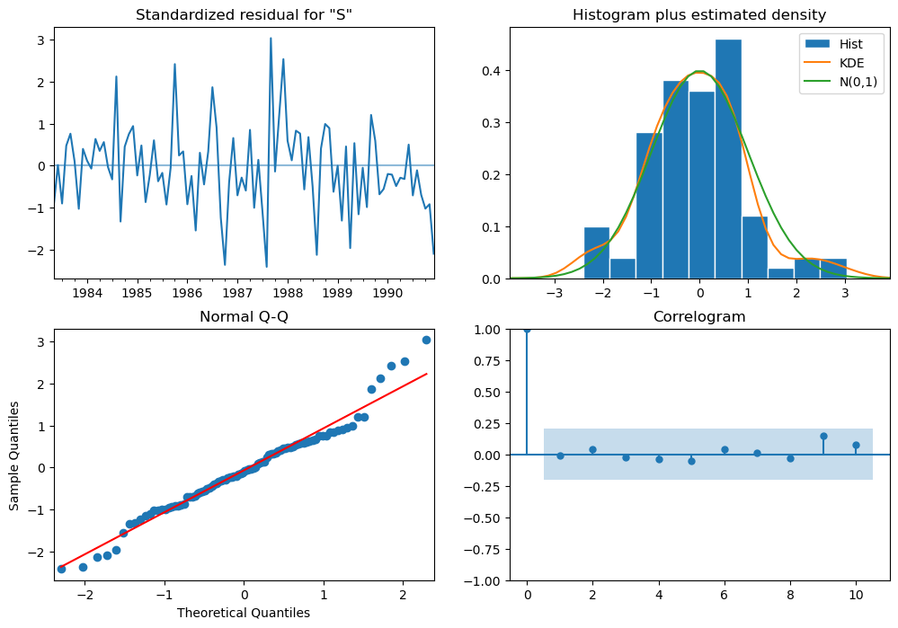

```python
# Plot diagnostics
results_auto_SARIMA.plot_diagnostics(figsize = (12, 8));
```

#### Observations

- From the model diagnostics plot, we can see that all the individual diagnostics plots almost follow the theoretical numbers and thus we cannot develop any pattern from these plots.

```python
# Predict on the Test Set using this model and evaluate the model.
predicted_auto_SARIMA = results_auto_SARIMA.get_forecast(steps = len(df_test))
```

```python
predicted_auto_SARIMA.summary_frame(alpha=0.05).head()
```

| Sparkling | mean | mean_se | mean_ci_lower | mean_ci_upper |
| --- | --- | --- | --- | --- |
| 1991-01-31 | 1342.068706 | 394.764904 | 568.343712 | 2115.793700 |
| 1991-02-28 | 1350.644786 | 419.547895 | 528.346022 | 2172.943550 |
| 1991-03-31 | 1578.492414 | 421.117248 | 753.117775 | 2403.867054 |
| 1991-04-30 | 1667.738276 | 432.624014 | 819.810789 | 2515.665762 |
| 1991-05-31 | 1320.628293 | 432.657602 | 472.634975 | 2168.621610 |

```python
rmse = mean_squared_error(df_test["Sparkling"], predicted_auto_SARIMA.predicted_mean, squared = False)
mape = mean_absolute_percentage_error(df_test["Sparkling"], predicted_auto_SARIMA.predicted_mean)
print("RMSE:", rmse, "\nMAPE:", mape)
```

```
RMSE: 611.1517468623412
MAPE: 26.814601885121164
```

```python
temp_resultsDf = pd.DataFrame({"RMSE": rmse, "MAPE": mape}
                           , index = ["SARIMA(3, 1, 3)(3, 0, 0, 12)"])

resultsDf = pd.concat([resultsDf, temp_resultsDf])
resultsDf
```

|  | RMSE | MAPE |
| --- | --- | --- |
| ARIMA (2, 1, 2) | 1299.980041 | 47.100033 |
| SARIMA(3, 1, 3)(3, 0, 0, 12) | 611.151747 | 26.814602 |

```python
resultsDf = resultsDf[["RMSE"]]
resultsDf.rename(columns = {"RMSE": "Test RMSE"}, inplace = True)
resultsDf
```

|  | Test RMSE |
| --- | --- |
| ARIMA (2, 1, 2) | 1299.980041 |
| SARIMA(3, 1, 3)(3, 0, 0, 12) | 611.151747 |

## Model Comparison and Final Model Selection

```python
comparison_model_table = pd.concat([resultsDf1, resultsDf])
comparison_model_table.sort_values(by = "Test RMSE")
```

|  | Test RMSE |
| --- | --- |
| Alpha=0.3, Beta=0.3, Gamma=0.3, TripleExponentialSmoothing | 361.397300 |
| Alpha=0.111, Beta=0.049, Gamma=0.362, TripleExponentialSmoothing | 404.286809 |
| SARIMA(3, 1, 3)(3, 0, 0, 12) | 611.151747 |
| Simple Average | 1275.081804 |
| RegressionOnTime | 1294.440103 |
| ARIMA (2, 1, 2) | 1299.980041 |
| Alpha = 0.04, SimpleExponentialSmoothing | 1304.927405 |
| Alpha = 0.3, SimpleExponentialSmoothing | 1935.507132 |
| Alpha=0.688, Beta=0.00009, DoubleExponentialSmoothing | 2007.238526 |
| Naive on Time | 3864.279352 |
| Alpha=0.3, Beta=0.3, DoubleExponentialSmoothing | 18259.110704 |

## Forecasting using Final Model

Based on the model-building exercise, let's build the most optimum model(s) on the complete data and predict 12 months into the future with appropriate confidence intervals/bands.

```python
model = ExponentialSmoothing(df["Sparkling"], trend = "additive", seasonal = "multiplicative", freq = "M")
# fit model
model_fit = model.fit(smoothing_level = 0.3, smoothing_trend = 0.3, smoothing_seasonal = 0.3, optimized = False, use_brute = True)
# make prediction
yhat = model_fit.predict(start = "31-08-1995", end = "31-08-1996")
```

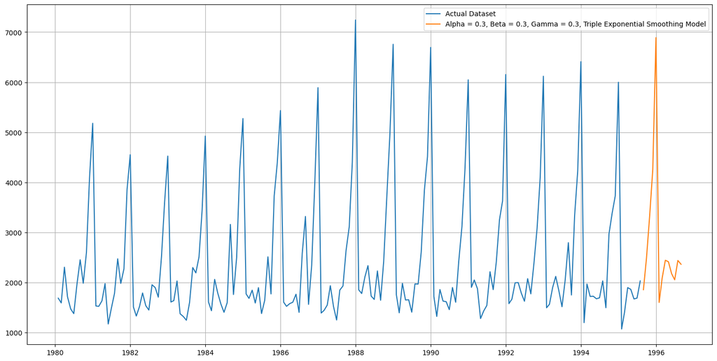

```python
plt.figure(figsize = (18, 9))
plt.plot(df["Sparkling"], label = "Actual Dataset")

plt.plot(yhat, label = "Alpha = 0.3, Beta = 0.3, Gamma = 0.3, Triple Exponential Smoothing Model")

plt.legend(loc = "best")
plt.grid();
```

```python
pred_1_df = pd.DataFrame({"lower_CI": yhat - 1.96*np.std(model_fit.resid, ddof = 1),
                          "prediction": yhat,
                          "upper_ci": yhat + 1.96*np.std(model_fit.resid, ddof = 1)})
pred_1_df.head()
```

|  | lower_CI | prediction | upper_ci |
| --- | --- | --- | --- |
| 1995-08-31 | 1014.069331 | 1854.686308 | 2695.303286 |
| 1995-09-30 | 1650.369143 | 2490.986121 | 3331.603098 |
| 1995-10-31 | 2498.588142 | 3339.205119 | 4179.822096 |
| 1995-11-30 | 3415.513796 | 4256.130773 | 5096.747751 |
| 1995-12-31 | 6048.795192 | 6889.412170 | 7730.029147 |

- In the above code, we have calculated the upper and lower confidence bands at 95% confidence level.
- Here we are taking the multiplier to be 1.96 as we want to plot with respect to a 95% confidence intervals.

```python
pred_1_df.tail()
```

|  | lower_CI | prediction | upper_ci |
| --- | --- | --- | --- |
| 1996-04-30 | 1573.333217 | 2413.950194 | 3254.567172 |
| 1996-05-31 | 1335.714857 | 2176.331834 | 3016.948811 |
| 1996-06-30 | 1212.044951 | 2052.661928 | 2893.278906 |
| 1996-07-31 | 1597.967939 | 2438.584916 | 3279.201894 |
| 1996-08-31 | 1522.187178 | 2362.804155 | 3203.421132 |

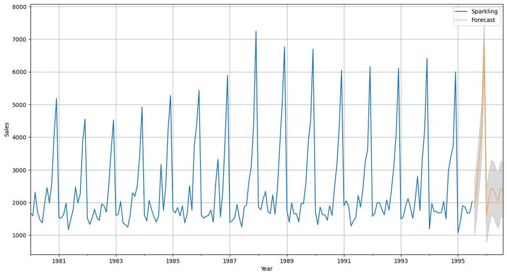

```python
# Plot the forecast along with the confidence band

axis = df.plot(label = "Actual", figsize = (15, 8))
pred_1_df["prediction"].plot(ax = axis, label = "Forecast", alpha = 0.5)
axis.fill_between(pred_1_df.index, pred_1_df["lower_CI"], pred_1_df["upper_ci"], color = "k", alpha = .15)
axis.set_xlabel("Year")
axis.set_ylabel("Sales")
plt.legend(loc = "best")
plt.grid()
plt.show()
```

## Business Insights and Recommendations

- For forecasting the future sales, using the tuned Triple Exponential Smoothing model with Alpha = 0.3, Beta = 0.3, Gamma = 0.3 gives the lowest RMSE value as compared to other time series models built and gives the best prediction.
- While it is understandable that sale of Sparkling wine increases during the festive period (November and December), it is necessary to understand why sales are very low across the other months of the years, especially months in the first half of the year.
- There is a need to obtain information on the company's customer base and segment it based on demographics and regions. This would help understand which regions generate the most and least sales as well as the age group the Sparkling wine appeals too.
- A research should be carried out in regions with poor sales to determine if the product should cease from being sold there or efforts need to be made to attract potential customers in the area. In regions of high sales, efforts should be made to sustain and improve it.
- An industry analysis should be conducted to discover if the trend in sales is similar to competitors or it is perculiar to ABC Estate Wines.